# Tutorial - vtamR pipeline - v0.3.0

# Summary

**vtamR** is a revised, completed version of VTAM (Validation and Taxonomic Assignation of Metabarcoding Data) rewritten in R. It is a complete metabarcoding pipeline:

- Sequence analyses from raw fastq files of amplicon sequences till Amplicon Sequence Variant (ASV) table of validated ASVs assigned to taxonomic groups.
- Handles technical or biological replicates of the same sample
- Uses positive and negative control samples to fine tune the filtering and reduce false positive and false negative occurrences.
- Can pool multiple data sets (results of earlier analyses)
- Can pool results from overlapping markers

**Novelties compared to VTAM:**

- As it is a series of R functions, `vtamR` is highly adaptable to include/exclude and order different steps of the analyses
- Includes swarm for denoising
- Graphic options
- Include functions to get statistics of each filtering steps (read and variant count etc.)
- The notion of marker and run has been dropped to simplify the analyses

# Installation

Please, follow the Installation instructions.

# Tutorial

## Set up

*Load library*

```r
library(vtamR)
```

*Set path to third party programs*

```r
# Example for Windows
cutadapt_path <- "C:/Users/Public/cutadapt"
vsearch_path <- "C:/Users/Public/vsearch-2.23.0-win-x86_64/bin/vsearch"
blast_path <- "C:/Users/Public/blast-2.16.0+/bin/blastn"
swarm_path <- "C:/Users/Public/swarm-3.1.5-win-x86_64/bin/swarm"
pigz_path <- "C:/Users/Public/pigz-win32/pigz" # optional
```

```r
#  Example for Linux
cutadapt_path <- "~/miniconda3/envs/vtam/bin/cutadapt"
vsearch_path <- "~/miniconda3/envs/vtam/bin/vsearch"
blast_path <- "~/miniconda3/envs/vtam/bin/blastn"
swarm_path <- "swarm" # swarm is in the PATH
pigz_path <- "pigz" # pigz is in the PATH
```

- **Adapt the path** to third party programs according to your installation (See Installation).

*Set general parameters*

```r
sep <- ","
outdir <- "~/vtamR_demo_out"
```

- `sep`: Separator used in csv files
- `outdir`: Name of the output directory. Make sure there is **no space in the path**.

*Input Data*

The demo files below are included with the `vtamR` package, which is why we use `system.file()` to access them in this tutorial. When using your own data, simply provide the file and directory names (e.g. `~/vtamR/fastq`)

```r
fastq_dir <- system.file("extdata/demo/fastq", package = "vtamR")
fastqinfo <-  system.file("extdata/demo/fastqinfo.csv", package = "vtamR")
mock_composition <-  system.file("extdata/demo/mock_composition.csv", package = "vtamR")
asv_list <-  system.file("extdata/demo/asv_list.csv", package = "vtamR")
```

- `fastq_dir`: Directory containing the input fastq files.
- fastqinfo: CSV file with information on input files, primers, tags, samples.
- mock_composition: CSV file with expected ASVs in mock samples. See How to make a mock composition file on how to create this file.
- asv_list: CSV file with ASVs from earlier data sets. Optional.

*Taxassign database*

Set the path to the database for taxonomic assignment and to the accompanying taxonomy file. For this example, we use a very small data base included in the `vtamR` package. To see how to get a real data base visit TaxAssign reference data base. When using your own data just enter the file names, without using the `system.file` function.

```r
taxonomy <- system.file("extdata/db_test/taxonomy_reduced.tsv", package = "vtamR")
blast_db <- system.file("extdata/db_test", package = "vtamR")
blast_db <- file.path(blast_db, "COInr_reduced")
```

- `taxonomy`: CSV file with taxonomic information
- `blast_db`: BLAST database

Details are in Reference database for taxonomic assignments section

*Check the format of input files*

The `CheckFileinfo` function tests if all obligatory columns are present, and makes some sanity checks. This can be helpful, since these files are produced by the users, and may contain errors difficult to spot by eye.

```r
CheckFileinfo(file=fastqinfo, dir=fastq_dir, file_type="fastqinfo")
```

```
#> [1] "Sample names are alphanumerical : OK"
#> [1] "Only IUPAC characters in tag_fw: OK"
#> [1] "Only IUPAC characters in tag_rv: OK"
#> [1] "Only IUPAC characters in primer_fw: OK"
#> [1] "Only IUPAC characters in primer_rv: OK"
#> [1] "Coherence between samples and sample_type: OK"
#> [1] "Coherence between samples and habitat: OK"
#> [1] "sample_type: OK"
#> [1] "Coherence between samples and replicates: OK"
#> [1] "File extension: OK"
#> [1] "Coherence between fw and rv fastq filename: OK"
#> [1] "Unique tag combinations : OK"
```

```r
CheckFileinfo(file=mock_composition, file_type="mock_composition")
```

```
#> [1] "Sample names are alphanumerical : OK"
#> [1] "Only IUPAC characters in ASV: OK"
#> [1] "Action types : OK"
```

```r
CheckFileinfo(file=asv_list, file_type="asv_list")
```

```
#> [1] "Only IUPAC characters in ASV: OK"
#> [1] "1 to 1 relation between asv_id and asv : OK"
```

> **Before starting the analyses, check the Tips – Good to Know section. It summarizes several general features and options of `vtamR` and will help you better understand how to run the functions effectively.**

## Merge - Demultiplex

- merged and quality filtered (`Merge`)
- demultiplexed and tags and primers trimmed off (`SortReads`)

See the From fastq to data frame on how to deal with other experimental design.

**Merge and quality filter**

`Merge` will make a single sequence from each read-pair. It can also be used for quality filtering.

`compress = FALSE` In the tutorial we will use uncompressed files, but see To compress or not to compress for the best strategy for you. See also Files to keep on how to handle the large intermediate files that should be compressed or deleted once the analyses are complete.

See `?Merge` for more options on quality filtering.

```r
merged_dir <- file.path(outdir, "merged")
fastainfo_df <- Merge(fastqinfo=fastqinfo, # csv or data frame with input filenames
                      fastq_dir=fastq_dir, # directory of input fasta files
                      vsearch_path=vsearch_path,
                      outdir=merged_dir, # directory of output fasta files
                      fastq_maxee=1, # Maximum Expected Error for each read
                      fastq_maxns=0, # no Ns in output
                      fastq_allowmergestagger=T, # reads might be longer than the marker
                      compress=FALSE # uncompressed output
                      )
```

**Randomly select sequences**

The `RandomSeq` function randomly selects `n` sequences (without replacement) from each input FASTA file listed in the `fastainfo` data frame.

This step can be useful to **normalize the number of reads across sequencing libraries**, but it is entirely up to you whether to include it in your workflow.

In this tutorial, I use `RandomSeq` to ensure that all replicate series (i.e., each FASTA file contains different replicates of the same samples) contain the same number of reads.

There are two different methods to perform random sampling:

*1. Using fastx_subsample command of VSEARCH (`use_vsearch = TRUE`)* This method is very **fast but only available on Linux-like** operating systems.

*2. Using R Only (`use_vsearch = FALSE`)* This version is slower but works on all operating systems.

The following example uses a **slower but cross-platform** version. See RandomSeq for more information.

```r
randomseq_dir <- file.path(outdir, "random_seq")
fastainfo_df <- RandomSeq(fastainfo = fastainfo_df, # input df (output of Merge)
                          fasta_dir = merged_dir, # directory of input fasta files.
                          outdir = randomseq_dir,  # directory of output fasta files.
                          use_vsearch  = FALSE, # use cross-platform version
                          n = 40000, # select n sequences from each file
                          compress = FALSE) # uncompressed output
```

**Demultiplex and Trim**

The `SortReads` function will demultiplex the fasta files according to the tag combinations and trim the primers from the reads.

See the help (`?SortReads`) for setting the correct parameters for demultiplexing and primer trimming:

- If `check_reverse` is TRUE, `SortReads` checks the reverse complementary stand as well.
- `sampleinfo_df` is updated version of `fastainfo`. This data frame and the files listed in it are the input of the `Dereplicate`.

```r
demultiplexed_dir <- file.path(outdir, "demultiplexed")
sampleinfo_df <- SortReads(fastainfo=fastainfo_df,  # input df (output of RandomSeq)
                           fasta_dir=randomseq_dir, # input directory
                           outdir=demultiplexed_dir,  # output directory
                           check_reverse=TRUE,
                           cutadapt_path=cutadapt_path,
                           vsearch_path=vsearch_path,
                           cutadapt_minimum_length = 170,
                           cutadapt_maximum_length = 185,
                           compress=FALSE
                           )
```

## Dereplicate

At this stage, you should have **one FASTA file per sample-replicate**, containing merged reads with tags and primers removed.

These FASTA files should now be **dereplicated**, and each unique sequence (ASV) will be assigned a numerical ID (asv_id). The result is a data frame (read_count_df) that can also be written to a **CSV file** if `outfile` is specified. Saving this file is recommended, as it serves as the starting point for filtering. You can test different filtering strategies from this file without needing to re-run the time-consuming merging, demultiplexing, and trimming steps.

If you wish to retain ASV IDs from a previous analysis, you can provide a reference file (asv_list) containing earlier ASVs and their IDs. The complete, updated list of ASVs will then be written to `output_asv_list`.

If only `output_asv_list` is provided (and `input_asv_list` is omitted), the function will write the full list of current ASVs with assigned IDs. This will be useful when analyzing further data sets to ensure consistent ASV IDs across studies.

```r
outfile <- file.path(outdir, "filter", "1_before_filter.csv")
updated_asv_list <- file.path(outdir, "ASV_list_with_IDs.csv")

read_count_df <- Dereplicate(sampleinfo_df,
                             dir=demultiplexed_dir,
                             outfile=outfile,
                             input_asv_list=asv_list,
                             output_asv_list=updated_asv_list
                             )
```

## Filter

`vtamR` has a large number of functions to **filter out ASVs** or **occurrences of ASVs** in a given sample-replicate, which are the results of **technical or biological problems associated with metabarcoding**.

The different filters

- can be **applied to the original data set** and then the results pooled together by using the `PoolFilters` function (accepting only occurrences that pass all filters)
- or can be **applied sequentially** in the order defined according to your needs.

In this section, I give an example using most filtering options. It is up to you to construct your own pipeline.

Each function returns a **data frame with the filtered output**. You can also write the results to a **csv file**. This can be useful for tracking the presence/absence of some of the ASVs/samples throughout the analyses using the HistoryBy and SummarizeBy functions.

I will **start the names of the output files by a number** to keep the order of the different steps and allow the SummarizeBy function to make final statistics at each step of the analyses.

We can also **follow the evolution of the number of reads and ASVs** remaining in the data set after each filtering steps. Let’s define a data frame (`stat_df`), that will contain this information, and we will complete it after each step.

```r
stat_df <- data.frame(parameters=character(),
                      asv_count=integer(),
                      read_count=integer(),
                      sample_count=integer(),
                      sample_replicate_count=integer())
```

Then we add a line with information on the unfiltered data set.

```r
stat_df <- GetStat(read_count_df, stat_df, stage="Input", params=NA)
```

- `params`: String containing the major parameters of each filtering steps.
- `stage`: String referring to the filtering step.

### Denoising by swarm

**Swarm** ([Mahé et al., 2015](https://peerj.com/articles/1420/)) is a powerful and quick computer program to denoise the data set by clustering ASVs that are likely to be the result of sequencing errors to ASVs representing real biological sequences. It will considerably reduce the number of ASVs.

Swarm can be run from the `ClusterASV` function of `vtamR`. For more detailed information on `ClusterASV`, see the Clustering or denosing tutorial.

When the aim the denoising the sequencing reads and not to cluster ASV to mOTUs, Swarm should be run with `d=1` and the `fastidious` algorithm. (See details in [Swarm’s Documentation](https://github.com/torognes/swarm/blob/master/man/swarm_manual.pdf))

It is possible to run `Swarm` separately for each sample (`by_sample=TRUE`) or at once for the whole data set. This second option is more efficient in reducing the number of ASVs but can cluster very similar real sequences appearing in different samples.

When interested in intra-specific variability, I suggest `by_sample=TRUE` or skipping this step, since `Swarm` can cluster together very similar real ASV.

The `group` argument pools all ASVs belonging to the same Swarm into one line under the asv_id of the Swarm’s centroid, summing read counts across ASVs while keeping the sample and replicate structure unchanged.

```r
by_sample <- TRUE
d=1
fastidious= TRUE
outfile <- file.path(outdir, "filter", "2_Swarm_by_sample.csv")

read_count_df <- ClusterASV(read_count_df,
                            method = "swarm",
                            swarm_d=d,
                            fastidious=fastidious,
                            by_sample=by_sample,
                            group = TRUE,
                            path=swarm_path,
                            outfile=outfile)


stat_df <- GetStat(read_count_df, stat_df, stage="Swarm", params=by_sample)
```

Let’s check the reduction of the number of variants after running `swarm`.

```r
knitr::kable(stat_df, format = "markdown")
```

|  | parameters | asv_count | read_count | sample_count | sample_replicate_count |
| --- | --- | --- | --- | --- | --- |
| Input | NA | 10037 | 116430 | 4 | 12 |
| Swarm | TRUE | 1098 | 116430 | 4 | 12 |

### LFNglobalReadCount

Although, SWARM has reduced considerably the number of ASVs, there are still many ASVs with low read count. The `LFNglobalReadCount` function filter out all ASVs with total read count bellow a threshold.

Let’s eliminate singletons and see how the number of ASV and reads are have changed.

```r
global_read_count_cutoff = 2
outfile <- file.path(outdir, "filter", "3_LFNglobalReadCount.csv")

read_count_df <- LFNglobalReadCount(read_count_df,
                                    cutoff=global_read_count_cutoff,
                                    outfile=outfile
                                    )

stat_df <- GetStat(read_count_df,
                   stat_df,
                   stage="LFNglobalReadCount",
                   params=global_read_count_cutoff
                   )
knitr::kable(stat_df, format = "markdown")
```

|  | parameters | asv_count | read_count | sample_count | sample_replicate_count |
| --- | --- | --- | --- | --- | --- |
| Input | NA | 10037 | 116430 | 4 | 12 |
| Swarm | TRUE | 1098 | 116430 | 4 | 12 |
| LFNglobalReadCount | 2 | 147 | 115431 | 4 | 12 |

### FilterIndel

This filter is **applicable only for coding sequences**. The idea is that if the length of the ASV differs from the most frequent ASV length by a number that is not a multiple of 3, it is likely to be an erroneous sequence or a pseudo-gene.

```r
outfile <- file.path(outdir, "filter", "4_FilterIndel.csv")

read_count_df <- FilterIndel(read_count_df, outfile=outfile)

stat_df <- GetStat(read_count_df, stat_df, stage="FilterIndel")

knitr::kable(stat_df, format = "markdown")
```

|  | parameters | asv_count | read_count | sample_count | sample_replicate_count |
| --- | --- | --- | --- | --- | --- |
| Input | NA | 10037 | 116430 | 4 | 12 |
| Swarm | TRUE | 1098 | 116430 | 4 | 12 |
| LFNglobalReadCount | 2 | 147 | 115431 | 4 | 12 |
| FilterIndel | NA | 143 | 115393 | 4 | 12 |

### FilterCodonStop

This filter is **applicable only for coding sequences**. It checks the number of codon STOPs in all 3 reading frames, and eliminates ASVs with STOP in all of them.

The numerical id of the genetic code can be chosen from [NCBI](https://www.ncbi.nlm.nih.gov/Taxonomy/Utils/wprintgc.cgi?chapter=cgencodes). By default, it is the invertebrate mitochondrial genetic code (5), since the STOP codons of this genetic codes are also STOP codons in almost all genetic codes.

```r
outfile <- file.path(outdir, "filter", "5_FilterCodonStop.csv")
genetic_code = 5

read_count_df <- FilterCodonStop(read_count_df, outfile=outfile, genetic_code=genetic_code)

stat_df <- GetStat(read_count_df, stat_df, stage="FilerCodonStop", params=genetic_code)

knitr::kable(stat_df, format = "markdown")
```

|  | parameters | asv_count | read_count | sample_count | sample_replicate_count |
| --- | --- | --- | --- | --- | --- |
| Input | NA | 10037 | 116430 | 4 | 12 |
| Swarm | TRUE | 1098 | 116430 | 4 | 12 |
| LFNglobalReadCount | 2 | 147 | 115431 | 4 | 12 |
| FilterIndel | NA | 143 | 115393 | 4 | 12 |
| FilerCodonStop | 5 | 143 | 115393 | 4 | 12 |

### FilterExternalContaminant

We start from the hypothesis that, in cases of slight external contamination, contaminant DNA may be amplified in negative control samples, since there is no competition with abundant target DNA. Conversely, in real or mock samples, the amplification of contaminant DNA is usually less efficient due to this competition.

This filter identifies ASVs whose read counts are higher in at least one negative control than in any other sample. These ASVs are considered potential contaminants and are removed from the dataset.

The `conta_file` will contain the data corresponding to the removed ASVs.

```r
conta_file <- file.path(outdir, "filter", "external_contamination.csv")
outfile <- file.path(outdir, "filter", "6_FilterCodonStop.csv")
read_count_df <- FilterExternalContaminant(read_count_df,
                          sampleinfo=sampleinfo_df,
                          conta_file=conta_file,
                          outfile=outfile)

stat_df <- GetStat(read_count_df, stat_df, stage="FilterExternalContaminant", params=NA)

knitr::kable(stat_df, format = "markdown")
```

|  | parameters | asv_count | read_count | sample_count | sample_replicate_count |
| --- | --- | --- | --- | --- | --- |
| Input | NA | 10037 | 116430 | 4 | 12 |
| Swarm | TRUE | 1098 | 116430 | 4 | 12 |
| LFNglobalReadCount | 2 | 147 | 115431 | 4 | 12 |
| FilterIndel | NA | 143 | 115393 | 4 | 12 |
| FilerCodonStop | 5 | 143 | 115393 | 4 | 12 |
| FilterExternalContaminant | NA | 132 | 115287 | 4 | 12 |

### FilterChimera

This function will run the `uchime3_denovo` function implemented in vsearch. It can be run sample by sample (`by_sample=T`; default), or on the whole data set at once.

FilterChimera will eliminate ASVs detected as chimeras when running on the whole dataset at once (`by_sample=F`). If `by_sample=T`, ASVs are eliminated if they have been identified as chimeras in at least `sample_prop` proportion of the samples where they are present.

- `abskew`: A chimera must be at least `abskew` times less frequent that the parental ASVs.

```r
abskew=2
by_sample = T
sample_prop = 0.8
outfile <- file.path(outdir, "filter", "7_FilterChimera.csv")

read_count_df <- FilterChimera(read_count_df, outfile=outfile, vsearch_path=vsearch_path, by_sample=by_sample, sample_prop=sample_prop, abskew=abskew)

params <- paste(abskew, by_sample, sample_prop, sep=";")
stat_df <- GetStat(read_count_df, stat_df, stage="FilterChimera", params=params)

knitr::kable(stat_df, format = "markdown")
```

|  | parameters | asv_count | read_count | sample_count | sample_replicate_count |
| --- | --- | --- | --- | --- | --- |
| Input | NA | 10037 | 116430 | 4 | 12 |
| Swarm | TRUE | 1098 | 116430 | 4 | 12 |
| LFNglobalReadCount | 2 | 147 | 115431 | 4 | 12 |
| FilterIndel | NA | 143 | 115393 | 4 | 12 |
| FilerCodonStop | 5 | 143 | 115393 | 4 | 12 |
| FilterExternalContaminant | NA | 132 | 115287 | 4 | 12 |
| FilterChimera | 2;TRUE;0.8 | 113 | 114776 | 4 | 12 |

### FilterRenkonen

Let’s eliminate aberrant replicates that are not similar to other replicates of the same sample.

We will calculate the renkonen distances among all pairs of replicates within sample.

```r
renkonen_within_df <- MakeRenkonenDistances(read_count_df, compare_all=FALSE)
```

Let’s make a density plot of the renkonen distances **Note:** This is a very small test dataset, so the graph you generate with your own data will likely look quite different.

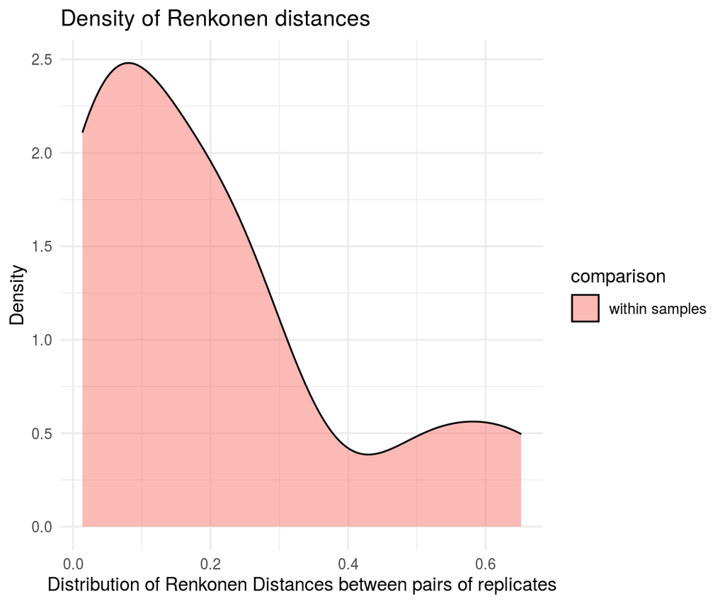

```r
DensityPlot_RenkonenDistance(renkonen_within_df)
```

We can also make a barplot of the renkonen distances, and use different colors for different sample types (real/mock/negative).

**Note**:

- `sampleinfo_df` contains a `sample` and `sample_type` columns, but any data frame with these columns would do.
- If you have restarted the analyses after the `SortReads` function, and  
  `sampleinfo_df` is not in your environment, just use the sampleinfo file (in the `vtamR_demo_out/demultiplexed/` directory).
- This is a very small test dataset, so the graph you generate with your own data will likely look quite different.

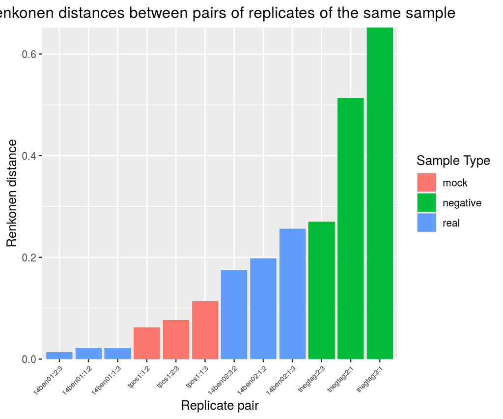

```r
Barplot_RenkonenDistance(renkonen_within_df, sampleinfo=sampleinfo_df, x_axis_label_size=6)
```

In this example, there are only a few distance values, so the density plot is not very informative. The bar plot shows that replicate 1 of the `tnegtag` sample (a negative control) differs substantially from the other two replicates, and setting `cutoff = 0.4` appears reasonable.

`read_count_df <- FilterRenkonen(read_count_df, cutoff = cutoff)`

This command filters out replicates whose Renkonen distances exceed the cutoff relative to most other replicates of the same sample. In this case, replicate 1 of the `tnegtag` sample will be removed.

An alternative way to determine the cutoff value is to set the `renkonen_distance_quantile` parameter instead of specifying a fixed `cutoff`. This parameter automatically sets the cutoff at the limit defined by the chosen quantile of the within-sample distance distribution. For example, setting `renkonen_distance_quantile = 0.9` will set the `cutoff` between the 9th and 10th decile (i.e., the 90th percentile) of the distance distribution.

Let’s choose this option.

```r
outfile <- file.path(outdir, "filter", "8_FilterRenkonen.csv")
renkonen_distance_quantile <- 0.9

read_count_df <- FilterRenkonen(read_count_df,
                                outfile=outfile,
                                renkonen_distance_quantile=renkonen_distance_quantile)
```

```
#> [1] "The cutoff value for Renkonen distances is  0.270201342281879"
```

```r
stat_df <- GetStat(read_count_df, stat_df, stage="FilerRenkonen", params=renkonen_distance_quantile)

knitr::kable(stat_df, format = "markdown")
```

|  | parameters | asv_count | read_count | sample_count | sample_replicate_count |
| --- | --- | --- | --- | --- | --- |
| Input | NA | 10037 | 116430 | 4 | 12 |
| Swarm | TRUE | 1098 | 116430 | 4 | 12 |
| LFNglobalReadCount | 2 | 147 | 115431 | 4 | 12 |
| FilterIndel | NA | 143 | 115393 | 4 | 12 |
| FilerCodonStop | 5 | 143 | 115393 | 4 | 12 |
| FilterExternalContaminant | NA | 132 | 115287 | 4 | 12 |
| FilterChimera | 2;TRUE;0.8 | 113 | 114776 | 4 | 12 |
| FilerRenkonen | 0.9 | 113 | 114749 | 4 | 11 |

### FilterPCRerror

If you have done the denoising step by **SWARM** (`ClusterASV`), this function probably redundant.

`FilterPCRerror` filters out an ASV if it is very similar to another, more frequent ASV. `max_mismatch` argument tells how many mismatches are allowed between a pair of ASV to be evaluated for PCR error. If the proportion of the read_counts of two similar ASVs is less or equal to `pcr_error_var_prop`, the less abundant ASV is flagged as a PCR error.

**OptimizePCRerror**

The default value of `pcr_error_var_prop` (0.1) is arbitrary. To choose a value adapted to your data set, you can use the `OptimizePCRerror` function.

`OptimizePCRerror`, will find all highly similar ASV pairs (`max_mismatch=1` by default) within a mock sample, where one ASV is expected, and the other is not. Their `read_count` ratio is printed in the output file.

The function considers only ASVs with more than `min_read_count` reads in the sample to avoid a ratio based on low read counts that are more influenced by stochastic events and will be probably filtered out anyway.

See details using the help: `?OptimizePCRerror`.

**Note:** I use `max_mismatch=2` in this example, to have some output in my very small (and artificial) data set, but I recommend you to use `max_mismatch=1`.

**Note**: If you do not know the exact sequences of the species present in your mock samples, and thus, you do not have the mock_composition file yet, read the How to make a mock_composition file.

```r
outfile <- file.path(outdir, "optimize", "OptimizePCRerror.csv")
OptimizePCRerror_df <- OptimizePCRerror(read_count_df,
                                        mock_composition=mock_composition,
                                        vsearch_path=vsearch_path,
                                        outfile=outfile,
                                        max_mismatch=2,
                                        min_read_count=5
                                        )
```

Let’s see the beginning of the output:

```r
knitr::kable(head(OptimizePCRerror_df), format = "markdown")
```

| sample | expected_read_count | unexpected_read_count | pcr_error_var_prop | expected_asv_id | unexpected_asv_id | expected_asv | unexpected_asv |
| --- | --- | --- | --- | --- | --- | --- | --- |
| tpos1 | 961 | 11 | 0.0114464 | 5 | 5744 | CTTATATTTTATTTTTGGTGCTTGATCAGGGATAGTGGGAACTTCTTTAAGAATTCTTATTCGAGCTGAACTTGGTCATGCGGGATCTTTAATCGGAGACGATCAAATTTACAATGTAATTGTTACTGCACACGCCTTTGTAATAATTTTTTTTATAGTTATACCTATTTTAATT | CCTTTATTTTATTTTTGGTGCTTGATCAGGGATAGTGGGAACTTCTTTAAGAATTCTTATTCGAGCTGAACTTGGTCATGCGGGATCTTTAATCGGAGACGATCAAATTTACAATGTAATTGTTACTGCACACGCCTTTGTAATAATTTTTTTTATAGTTATACCTATTTTAATT |
| tpos1 | 961 | 5 | 0.0052029 | 5 | 1677 | CTTATATTTTATTTTTGGTGCTTGATCAGGGATAGTGGGAACTTCTTTAAGAATTCTTATTCGAGCTGAACTTGGTCATGCGGGATCTTTAATCGGAGACGATCAAATTTACAATGTAATTGTTACTGCACACGCCTTTGTAATAATTTTTTTTATAGTTATACCTATTTTAATT | CTTATATTTTATTTTTGGTGCTTGATCAGGGATAGTGGGAACTTCTTTAAGAATTCTTATTCGAGCTGAACTTGGTCATGCGGGATCTTTAATCGGAGACGATCAAATTTACAATGTAATTGTTACTGCACACGCCTTTGTAATAATTTTTTTTATAGTGATACCTATTATAATT |
| tpos1 | 12272 | 12 | 0.0009778 | 6 | 6016 | TCTATATTTCATTTTTGGTGCTTGGGCAGGTATGGTAGGTACCTCATTAAGACTTTTAATTCGAGCCGAGTTGGGTAACCCGGGTTCATTAATTGGGGACGATCAAATTTATAACGTAATCGTAACTGCTCATGCCTTTATTATGATTTTTTTTATAGTGATACCTATTATAATT | TCTATATTTCATTTTTGGTGCTTGGGCAGGTATGGTAGGTACCTCATTAAGACTTTTAATTCGAGCCGAGTTGGGTAACCCGGGTTCATTAATTGGGGACGATCAAATTTATAACGTAATCGTAACTGATCATGGCTTTATTATGATTTTTTTTATAGTGATACCTATTATAATT |

**FilterPCRerror**

It seems that Swarm has done a good job. The highest read count ratio is 0.01 in the output of `OptimizePCRerror`. This should be taken as a lower limit to `pcr_error_var_prop`. Let’s use 0.05 for filtering out PCR errors sample by sample.

See the help for more detail `?FilterPCRerror`.

**Note:** Again, I use `max_mismatch <- 2` in this example, since I have used this value for `OptimizePCRerror`, but I recommend you to use `max_mismatch <- 1`.

```r
pcr_error_var_prop <- 0.05
max_mismatch <- 2
outfile <- file.path(outdir, "filter", "9_FilterPCRerror.csv")

read_count_df <- FilterPCRerror(read_count_df,
                                outfile=outfile,
                                vsearch_path=vsearch_path,
                                pcr_error_var_prop=pcr_error_var_prop,
                                max_mismatch=max_mismatch
                                )

params <- paste(pcr_error_var_prop, max_mismatch, by_sample, sep=";")
stat_df <- GetStat(read_count_df, stat_df, stage="FilterPCRerror", params=params)

knitr::kable(stat_df, format = "markdown")
```

|  | parameters | asv_count | read_count | sample_count | sample_replicate_count |
| --- | --- | --- | --- | --- | --- |
| Input | NA | 10037 | 116430 | 4 | 12 |
| Swarm | TRUE | 1098 | 116430 | 4 | 12 |
| LFNglobalReadCount | 2 | 147 | 115431 | 4 | 12 |
| FilterIndel | NA | 143 | 115393 | 4 | 12 |
| FilerCodonStop | 5 | 143 | 115393 | 4 | 12 |
| FilterExternalContaminant | NA | 132 | 115287 | 4 | 12 |
| FilterChimera | 2;TRUE;0.8 | 113 | 114776 | 4 | 12 |
| FilerRenkonen | 0.9 | 113 | 114749 | 4 | 11 |
| FilterPCRerror | 0.05;2;TRUE | 107 | 114709 | 4 | 11 |

### LFNsampleReplicate

`LFNsampleReplicate` will eliminate occurrences with very low read counts compared to the total number of reads in the sample-replicate. The default cutoff proportion is 0.001. We can have an idea of the maximum value of this cutoff, by examining the proportions of expected ASVs in the mock samples using the `OptimizeLFNsampleReplicate` function.

**OptimizeLFNsampleReplicate**

**Note**: If you do not know the exact sequences of the species present in your mock samples, and thus, you do not have the mock_composition file yet, read the How to make a mock_composition file.

```r
outfile = file.path(outdir, "optimize", "OptimizeLFNsampleReplicate.csv")
OptimizeLFNsampleReplicate_df <- OptimizeLFNsampleReplicate(read_count=read_count_df,
                                                            mock_composition=mock_composition,
                                                            outfile=outfile)
knitr::kable(head(OptimizeLFNsampleReplicate_df), format = "markdown")
```

| sample | replicate | action | asv_id | lfn_sample_replicate_cutoff | read_count | read_count_sample_replicate | asv | taxon |
| --- | --- | --- | --- | --- | --- | --- | --- | --- |
| tpos1 | 3 | keep | 1 | 0.0046 | 95 | 20412 | ACTATATTTTATTTTTGGGGCTTGATCCGGAATGCTGGGCACCTCTCTAAGCCTTCTAATTCGTGCCGAGCTGGGGCACCCGGGTTCTTTAATTGGCGACGATCAAATTTACAATGTAATCGTCACAGCCCATGCTTTTATTATGATTTTTTTCATGGTTATGCCTATTATAATC | Caenis pusilla |
| tpos1 | 1 | keep | 3 | 0.0085 | 186 | 21829 | CCTTTATCTTGTATTTGGTGCCTGGGCCGGAATGGTAGGGACCGCCCTAAGCCTTCTTATTCGGGCCGAACTAAGCCAGCCTGGCTCGCTATTAGGTGATAGCCAAATTTATAATGTTATTGTTACCGCCCACGCCTTCGTAATAATTTTCTTTATAGTCATGCCAATTCTCATT | Phoxinus phoxinus |
| tpos1 | 2 | keep | 3 | 0.0087 | 239 | 27184 | CCTTTATCTTGTATTTGGTGCCTGGGCCGGAATGGTAGGGACCGCCCTAAGCCTTCTTATTCGGGCCGAACTAAGCCAGCCTGGCTCGCTATTAGGTGATAGCCAAATTTATAATGTTATTGTTACCGCCCACGCCTTCGTAATAATTTTCTTTATAGTCATGCCAATTCTCATT | Phoxinus phoxinus |
| tpos1 | 2 | keep | 1 | 0.0088 | 241 | 27184 | ACTATATTTTATTTTTGGGGCTTGATCCGGAATGCTGGGCACCTCTCTAAGCCTTCTAATTCGTGCCGAGCTGGGGCACCCGGGTTCTTTAATTGGCGACGATCAAATTTACAATGTAATCGTCACAGCCCATGCTTTTATTATGATTTTTTTCATGGTTATGCCTATTATAATC | Caenis pusilla |
| tpos1 | 3 | keep | 3 | 0.0092 | 189 | 20412 | CCTTTATCTTGTATTTGGTGCCTGGGCCGGAATGGTAGGGACCGCCCTAAGCCTTCTTATTCGGGCCGAACTAAGCCAGCCTGGCTCGCTATTAGGTGATAGCCAAATTTATAATGTTATTGTTACCGCCCACGCCTTCGTAATAATTTTCTTTATAGTCATGCCAATTCTCATT | Phoxinus phoxinus |
| tpos1 | 2 | keep | 5 | 0.0119 | 326 | 27184 | CTTATATTTTATTTTTGGTGCTTGATCAGGGATAGTGGGAACTTCTTTAAGAATTCTTATTCGAGCTGAACTTGGTCATGCGGGATCTTTAATCGGAGACGATCAAATTTACAATGTAATTGTTACTGCACACGCCTTTGTAATAATTTTTTTTATAGTTATACCTATTTTAATT | Synorthocladius semivirens |

The lowest proportion of read count of an expected ASV to the total read count of its sample-relicate is 0.0047 (Sequence of *Caenis pusilla* in the replicate 3 of tpos1 mock sample). A cutoff values for `LFNsampleReplicate` higher than this will eliminate some of the expected occurrences and create false negatives. Therefore, we choose 0.004 as a cutoff.

**LFNsampleReplicate**

```r
lfn_sample_replicate_cutoff <- 0.004
outfile <- file.path(outdir, "filter", "10_LFNsampleReplicate.csv")

read_count_df <- LFNsampleReplicate(read_count_df,
                                    cutoff=lfn_sample_replicate_cutoff,
                                    outfile=outfile
                                    )

stat_df <- GetStat(read_count_df,
                   stat_df,
                   stage="LFNsampleReplicate",
                   params=lfn_sample_replicate_cutoff
                   )

knitr::kable(stat_df, format = "markdown")
```

|  | parameters | asv_count | read_count | sample_count | sample_replicate_count |
| --- | --- | --- | --- | --- | --- |
| Input | NA | 10037 | 116430 | 4 | 12 |
| Swarm | TRUE | 1098 | 116430 | 4 | 12 |
| LFNglobalReadCount | 2 | 147 | 115431 | 4 | 12 |
| FilterIndel | NA | 143 | 115393 | 4 | 12 |
| FilerCodonStop | 5 | 143 | 115393 | 4 | 12 |
| FilterExternalContaminant | NA | 132 | 115287 | 4 | 12 |
| FilterChimera | 2;TRUE;0.8 | 113 | 114776 | 4 | 12 |
| FilerRenkonen | 0.9 | 113 | 114749 | 4 | 11 |
| FilterPCRerror | 0.05;2;TRUE | 107 | 114709 | 4 | 11 |
| LFNsampleReplicate | 0.004 | 50 | 113109 | 4 | 11 |

### FilterMinReplicate 1

To ensure repeatability, we can accept occurrences if they are present in at least `min_replicate_number` replicates of the sample (2 by default).

```r
min_replicate_number <- 2
outfile <- file.path(outdir, "filter", "11_FilterMinReplicate.csv")

read_count_df <- FilterMinReplicate(read_count_df,
                                    cutoff=min_replicate_number,
                                    outfile=outfile
                                    )
stat_df <- GetStat(read_count_df,
                   stat_df,
                   stage="FilterMinReplicate",
                   params=min_replicate_number
                   )

knitr::kable(stat_df, format = "markdown")
```

|  | parameters | asv_count | read_count | sample_count | sample_replicate_count |
| --- | --- | --- | --- | --- | --- |
| Input | NA | 10037 | 116430 | 4 | 12 |
| Swarm | TRUE | 1098 | 116430 | 4 | 12 |
| LFNglobalReadCount | 2 | 147 | 115431 | 4 | 12 |
| FilterIndel | NA | 143 | 115393 | 4 | 12 |
| FilerCodonStop | 5 | 143 | 115393 | 4 | 12 |
| FilterExternalContaminant | NA | 132 | 115287 | 4 | 12 |
| FilterChimera | 2;TRUE;0.8 | 113 | 114776 | 4 | 12 |
| FilerRenkonen | 0.9 | 113 | 114749 | 4 | 11 |
| FilterPCRerror | 0.05;2;TRUE | 107 | 114709 | 4 | 11 |
| LFNsampleReplicate | 0.004 | 50 | 113109 | 4 | 11 |
| FilterMinReplicate | 2 | 32 | 111796 | 4 | 11 |

### LFNvariant and LFNreadCount

The `LFNvariant` filter removes occurrences with very low read counts relative to the total number of reads of their ASV. By default, the cutoff proportion is 0.001.

This filter is designed to remove spurious detections caused by **tag-jumps** or light **cross-sample contamination**.

The `LFNreadCount` filter, on the other hand, removes occurrences with absolute read counts below a fixed threshold, which is set to 10 by default.

**Choosing the Best Cutoff Values**

The function `OptimizeLFNreadCountLFNvariant` helps determine the most appropriate cutoff values for both filters. It evaluates a range of cutoff combinations and counts the resulting number of false positives, false negatives, and true positives.

To run this optimization, you need a `known_occurrences_df` data frame that identifies occurrences known to be **TPs (true positives)** or **FPs (false positives)**.

There are two ways to obtain the `known_occurrences_df` data frame:

**1. Full control**

You can generate it manually by running the `MakeKnownOccurrences` function. You may then review or edit the resulting `known_occurrences_df` as needed before passing it as an input to `OptimizeLFNreadCountLFNvariant`.

**2. Automatic generation**

Alternatively, you can set `known_occurrences = NULL` (the default) and provide values for the `mock_composition`, `sampleinfo`, and `habitat_proportion` arguments. In this case, `OptimizeLFNreadCountLFNvariant` will automatically call `MakeKnownOccurrences` and use its output to estimate the optimal cutoff values.

All data frames generated by `MakeKnownOccurrences` are written as CSV files to the specified `outdir`. The main output of `OptimizeLFNreadCountLFNvariant` — which summarizes the performance of different cutoff combinations — is also saved to `outdir` to assist in selecting the most appropriate filter thresholds.

Let’s use the second approach, where the `known_occurrences_df` is generated **automatically** by `OptimizeLFNreadCountLFNvariant`. If you prefer to create it manually, see the `MakeKnownOccurrences` section.

**OptimizeLFNreadCountLFNvariant**

In `OptimizeLFNreadCountLFNvariant`, the `LFNreadCount` and `LFNvariant` functions are run for a series of cutoff value combinations of the two filters, followed by `FilterMinReplicate`. For each parameter combination, the number of **FN**, **TP**, and **FP** is reported. Chose the less stringent parameter setting that minimizes, FN and FP.

Here we will use the default range of cutoffs to test, but you can set the minimum, the maximum and the increment for the cutoff values for both filters. (see `?OptimizeLFNreadCountLFNvariant`). We set `min_replicate_number` to 2, to eliminate non-repeatable occurrences among the three replicates of each sample.

```r
outdir = file.path(outdir, "OptimizeLFNreadCountLFNvariant")

OptimizeLFNreadCountLFNvariant_df <- OptimizeLFNreadCountLFNvariant(
  read_count_df,
  mock_composition = mock_composition,
  sampleinfo = sampleinfo_df,
  habitat_proportion = 0.5,
  known_occurrences=NULL,
  outdir= outdir,
  min_replicate_number=2
  )

#head(OptimizeLFNreadCountLFNvariant_df)
knitr::kable(head(OptimizeLFNreadCountLFNvariant_df), format = "markdown")
```

| lfn_read_count_cutoff | lnf_variant_cutoff | FN | TP | FP |
| --- | --- | --- | --- | --- |
| 10 | 0.001 | 0 | 6 | 4 |
| 15 | 0.001 | 0 | 6 | 4 |
| 20 | 0.001 | 0 | 6 | 4 |
| 25 | 0.001 | 0 | 6 | 4 |
| 30 | 0.001 | 0 | 6 | 4 |
| 35 | 0.001 | 0 | 6 | 4 |

**LFNvariant, LFNreadCount**

From the output, we choose 0.001 for the cutoff of `LFNvariant` and 10 for `LFNreadCount`, since this is the less stringent combination that keeps all expected occurrences (6 TP, 0 FN), and has less FP (4 FP).

We will run the two filters on the same input data frame (for which the parameters has been optimized), and pool the results by accepting only occurrences that pass both filters by the `PoolFilters` function.

See `?LFNvariant, ?LFNreadCount` and `?PoolFilters` for details.

LFNvariant

```r
lnf_variant_cutoff = 0.001
outfile <- file.path(outdir, "filter", "12_LFNvariant.csv")

read_count_df_lnf_variant <- LFNvariant(read_count_df,
                                        cutoff=lnf_variant_cutoff,
                                        outfile=outfile
                                        )
stat_df <- GetStat(read_count_df_lnf_variant,
                   stat_df,
                   stage="LFNvariant",
                   params=lnf_variant_cutoff)
```

LFNreadCount

```r
lfn_read_count_cutoff <- 10
outfile <- file.path(outdir, "filter", "13_LFNreadCount.csv")

read_count_df_lfn_read_count <- LFNreadCount(read_count_df,
                                             cutoff=lfn_read_count_cutoff,
                                             outfile=outfile
                                             )
stat_df <- GetStat(read_count_df_lfn_read_count,
                   stat_df, stage="LFNreadCount",
                   params=lfn_read_count_cutoff
                   )
```

Combine results

```r
outfile <- file.path(outdir, "filter", "14_poolLFN.csv")
read_count_df <- PoolFilters(read_count_df_lfn_read_count,
                             read_count_df_lnf_variant,
                             outfile=outfile
                             )
stat_df <- GetStat(read_count_df,
                   stat_df,
                   stage="FilterLFN"
                   )
# delete temporary data frames
rm(read_count_df_lfn_read_count)
rm(read_count_df_lnf_variant)

knitr::kable(stat_df, format = "markdown")
```

|  | parameters | asv_count | read_count | sample_count | sample_replicate_count |
| --- | --- | --- | --- | --- | --- |
| Input | NA | 10037 | 116430 | 4 | 12 |
| Swarm | TRUE | 1098 | 116430 | 4 | 12 |
| LFNglobalReadCount | 2 | 147 | 115431 | 4 | 12 |
| FilterIndel | NA | 143 | 115393 | 4 | 12 |
| FilerCodonStop | 5 | 143 | 115393 | 4 | 12 |
| FilterExternalContaminant | NA | 132 | 115287 | 4 | 12 |
| FilterChimera | 2;TRUE;0.8 | 113 | 114776 | 4 | 12 |
| FilerRenkonen | 0.9 | 113 | 114749 | 4 | 11 |
| FilterPCRerror | 0.05;2;TRUE | 107 | 114709 | 4 | 11 |
| LFNsampleReplicate | 0.004 | 50 | 113109 | 4 | 11 |
| FilterMinReplicate | 2 | 32 | 111796 | 4 | 11 |
| LFNvariant | 0.001 | 32 | 111738 | 4 | 11 |
| LFNreadCount | 10 | 31 | 111761 | 4 | 11 |
| FilterLFN | NA | 31 | 111717 | 4 | 10 |

### FilterMinReplicate 2

Let’s run again `FilterMinReplicate` to ensure repeatability among replicates of the sample (2 by default).

```r
min_replicate_number <- 2
outfile <- file.path(outdir, "filter", "15_FilterMinReplicate.csv")

read_count_df <- FilterMinReplicate(read_count_df,
                                    cutoff=min_replicate_number,
                                    outfile=outfile
                                    )
stat_df <- GetStat(read_count_df,
                   stat_df,
                   stage="FilterMinReplicate",
                   params=min_replicate_number
                   )

knitr::kable(stat_df, format = "markdown")
```

|  | parameters | asv_count | read_count | sample_count | sample_replicate_count |
| --- | --- | --- | --- | --- | --- |
| Input | NA | 10037 | 116430 | 4 | 12 |
| Swarm | TRUE | 1098 | 116430 | 4 | 12 |
| LFNglobalReadCount | 2 | 147 | 115431 | 4 | 12 |
| FilterIndel | NA | 143 | 115393 | 4 | 12 |
| FilerCodonStop | 5 | 143 | 115393 | 4 | 12 |
| FilterExternalContaminant | NA | 132 | 115287 | 4 | 12 |
| FilterChimera | 2;TRUE;0.8 | 113 | 114776 | 4 | 12 |
| FilerRenkonen | 0.9 | 113 | 114749 | 4 | 11 |
| FilterPCRerror | 0.05;2;TRUE | 107 | 114709 | 4 | 11 |
| LFNsampleReplicate | 0.004 | 50 | 113109 | 4 | 11 |
| FilterMinReplicate | 2 | 32 | 111796 | 4 | 11 |
| LFNvariant | 0.001 | 32 | 111738 | 4 | 11 |
| LFNreadCount | 10 | 31 | 111761 | 4 | 11 |
| FilterLFN | NA | 31 | 111717 | 4 | 10 |
| FilterMinReplicate1 | 2 | 30 | 111600 | 3 | 9 |

### Get performance metrics

```r
missing_occurrences <- file.path(outdir, "Missing_occurrences.csv")
performance_metrics <- file.path(outdir, "Performance_metrics.csv")
known_occurrences <- file.path(outdir, "Known_occurrences.csv")

results <- MakeKnownOccurrences(read_count_df,
                                sampleinfo=sampleinfo_df,
                                mock_composition=mock_composition,
                                known_occurrences=known_occurrences,
                                missing_occurrences=missing_occurrences,
                                performance_metrics=performance_metrics
                                )
# give explicit names to the 3 output data frames
known_occurrences_df <- results[[1]]
missing_occurrences_df <- results[[2]]
performance_metrics_df <- results[[3]]

knitr::kable(performance_metrics_df, format = "markdown")
```

| TP | FP | FN | Precision | Sensitivity |
| --- | --- | --- | --- | --- |
| 6 | 4 | 0 | 0.6 | 1 |

## TaxAssign

If you have already assigned ASV to taxa, (before making the mock_composition file) you can use the same output (`asv_tax` data frame) and skip this step.

See the brief description of the algorithm with `?TaxAssign`.

For the format of `taxonomy` and `blast_db` check the Reference database for taxonomic assignments section. You can also download a ready to use COI database (See Installation).

```r
outfile <- file.path(outdir, "TaxAssign.csv")

asv_tax <- TaxAssign(asv=read_count_df,
                     taxonomy=taxonomy,
                     blast_db=blast_db,
                     blast_path=blast_path,
                     outfile=outfile
                     )
```

## Make mOTUs

If you are not interested in intra-specific variation, the ASV can be clustered to mOTUs.

### Algorithm and Clustering parameters

The `ClusterASV` function supports two algorithms for clustering ASVs:

- `method = "vsearch"`: This approach uses VSEARCH’s `cluster_size` command, a greedy, centroid-based algorithm that ranks ASVs by decreasing read count. As a result, cluster centroids correspond to the most abundant ASVs. The cluster radius is controlled by the `identity` parameter.
- `method = "swarm"`: Swarm is a fast, iterative clustering method that groups ASVs differing by `d` or fewer nucleotides. Clusters form around local abundance peaks and are largely unaffected by the order of input sequences.

The main parameters are `identity` for VSEARCH and `swarm_d` for SWARM. In this tutorial, we’ll focus on determining an appropriate `identity` threshold for clustering with VSEARCH, but a similar approach applies to SWARM.

To choose a suitable threshold, you can visualize the distribution of pairwise identities between ASVs—comparing pairs within the same cluster versus those from different clusters—using the function `PairwiseIdentityPlotPerClusterIdentityThreshold` (for VSEARCH). If you’re clustering with SWARM, see `?PairwiseIdentityPlotPerSwarmD` for the equivalent plot.

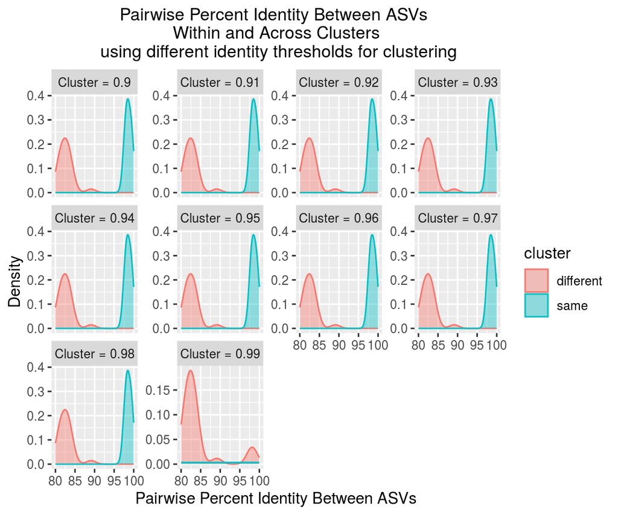

```r
outfile <- file.path(outdir, "cluster", "pairwise_identities_vsearch.csv")
plotfile <- file.path(outdir, "cluster", "PairwiseIdentityPlotPerClusterIdentityThreshold.png")

plot_vsearch <- PairwiseIdentityPlotPerClusterIdentityThreshold(read_count_df,
                                            identity_min=0.9,
                                            identity_max=0.99,
                                            identity_increment=0.01,
                                            min_id = 0.8,
                                            vsearch_path=vsearch_path,
                                            outfile=outfile,
                                            plotfile=plotfile)

print(plot_vsearch)
```

**Note:** This graph is based on a **very small** test dataset and is therefore not informative. Below is the graph obtained using the complete (though still relatively small) original dataset.

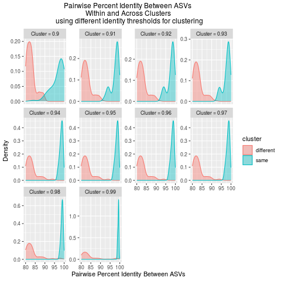

Pairwise Identity Plot Per Cluster Identity Threshold for the original data

Clusters can also be classified based on the taxonomic assignments of the ASVs they contain:

- `closed`: All ASVs in the cluster are assigned to the same taxon, and every ASV belonging to that taxon is found exclusively within this cluster.
- `open`: All ASVs in the cluster share the same taxonomic assignment, but additional ASVs of that taxon appear in other clusters.
- `hybrid`: The cluster includes ASVs assigned to multiple taxa.

This classification can be performed after clustering ASVs across a range of parameter values for `identity` (VSEARCH) or `swarm_d` (SWARM). The number of clusters in each category can then be plotted for each parameter setting. A clustering parameter that maximizes the number of `closed` clusters while minimizing the number of `open` and `hybrid` ones is often a good candidate for defining mOTUs.

(See `?PlotClusterClassification` for details on setting parameters when using SWARM.)

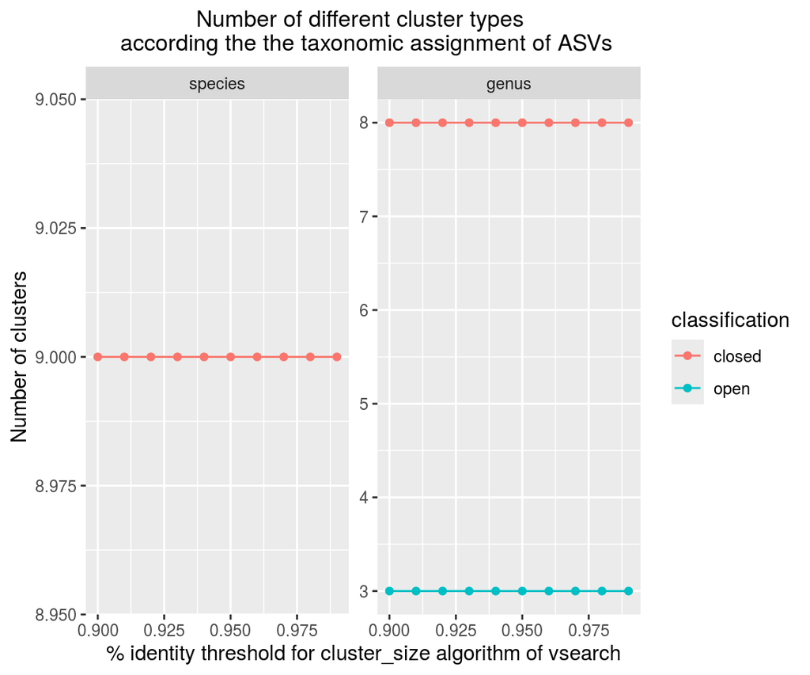

```r
outfile <- file.path(outdir, "cluster", "classification_vsearch.csv")
plotfile <- file.path(outdir, "cluster", "PlotClusterClasstification_vsearch.png")

scatterplot_vsearch <- PlotClusterClasstification(
                        read_count=read_count_df,
                        taxa=asv_tax,
                        clustering_method="vsearch",
                        cluster_params=c(0.90, 0.91, 0.92, 0.93, 0.94, 0.95, 0.96, 0.97, 0.98, 0.99),
                        vsearch_path=vsearch_path,
                        taxlevels= c("species", "genus"),
                        outfile=outfile,
                        plotfile=plotfile)

print(scatterplot_vsearch)
```

**Note:** This graph is based on a **very small** test dataset and is therefore not informative. Below is the graph obtained using the complete (though still relatively small) original dataset.

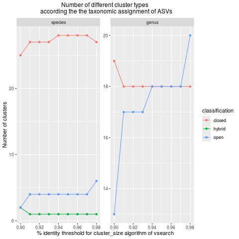

Plot ClusterClasstification for the original data

Even the original dataset is relatively small, and the graphs do not show strong differences between parameter values. Nevertheless, several conclusions can be drawn:

- At clustering thresholds below 0.94, the pairwise identity distribution among ASVs within the same cluster becomes bimodal. This likely indicates that ASVs from different taxa (species) are being grouped together, suggesting the clustering identity threshold should be **at least 0.94**.
- The number of `closed` clusters at the species level is highest between **0.94 and 0.97**, while the numbers of `open` and `hybrid` clusters remain relatively low in this range.
- Taken together, these results suggest that a clustering threshold between **0.94 and 0.97** is appropriate for defining mOTUs as proxies for species.

### Cluster ASVs to mOTUs

The `ClusterASV` function can perform clustering using either VSEARCH (`method = "vsearch"`) or SWARM (`method = "swarm"`).

The output format is controlled by the `group` argument:

- `group = TRUE`: ASVs belonging to the same cluster are aggregated into a single row. In this case, the `asv_id` and `asv` columns contain the identifier and sequence of the cluster’s centroid. Read counts are summed across ASVs, while sample and replicate structure remain unchanged.
- `group = FALSE`: The function returns the original ASV table with an additional `cluster_id` column, so each row still represents a single ASV.

Clustering can be performed on the entire data set or separately for each sample. When the goal is to define mOTUs, it is recommended to cluster all ASVs together (`by_sample = FALSE`).

Attention! If clustering is done by_sample (`by_sample = TRUE`) and `group==FALSE`, the same `asv_id`, can have different `cluster_id` in different samples.

Below, we’ll cluster the data using VSEARCH with an identity threshold of `0.97`. (See `?ClusterASV` for guidance on adjusting parameters when using SWARM.)

```r
outfile <- file.path(outdir, "filter", "16_mOTU_vsearch.csv")
identity <- 0.97
read_count_samples_df_ClusterSize <- ClusterASV(read_count_df,
                                                 method = "vsearch",
                                                 identity = 0.97,
                                                 group = TRUE,
                                                 by_sample=FALSE,
                                                 path=vsearch_path,
                                                 outfile=outfile)

stat_df <- GetStat(read_count_samples_df_ClusterSize,
                   stat_df,
                   stage="ClusterASV_vsearch",
                   param=identity
                   )
knitr::kable(stat_df, format = "markdown")
```

|  | parameters | asv_count | read_count | sample_count | sample_replicate_count |
| --- | --- | --- | --- | --- | --- |
| Input | NA | 10037 | 116430 | 4 | 12 |
| Swarm | TRUE | 1098 | 116430 | 4 | 12 |
| LFNglobalReadCount | 2 | 147 | 115431 | 4 | 12 |
| FilterIndel | NA | 143 | 115393 | 4 | 12 |
| FilerCodonStop | 5 | 143 | 115393 | 4 | 12 |
| FilterExternalContaminant | NA | 132 | 115287 | 4 | 12 |
| FilterChimera | 2;TRUE;0.8 | 113 | 114776 | 4 | 12 |
| FilerRenkonen | 0.9 | 113 | 114749 | 4 | 11 |
| FilterPCRerror | 0.05;2;TRUE | 107 | 114709 | 4 | 11 |
| LFNsampleReplicate | 0.004 | 50 | 113109 | 4 | 11 |
| FilterMinReplicate | 2 | 32 | 111796 | 4 | 11 |
| LFNvariant | 0.001 | 32 | 111738 | 4 | 11 |
| LFNreadCount | 10 | 31 | 111761 | 4 | 11 |
| FilterLFN | NA | 31 | 111717 | 4 | 10 |
| FilterMinReplicate1 | 2 | 30 | 111600 | 3 | 9 |
| ClusterASV_vsearch | 0.97 | 26 | 111600 | 3 | 9 |

## Print output

The `WriteASVtable` function restructures the `read_count_df` data frame so that **samples are represented in columns** and **ASVs (or mOTU centroids)** appear in rows—converting the table from long format to wide format.

Additional information can be included in the output:

- Taxonomic assignment: (`asv_tax`)
- Totals by ASV: The total number of reads and samples for each ASV (`add_sums_by_asv`)
- Totals by sample: The total number of reads and ASVs for each sample (`add_sums_by_sample`)
- Expected ASVs in mock samples: Adds a column for each mock sample with its expected occurrences (`add_expected_asv`)
- Filtered samples: Adds a column for each sample that have been filtered out (`add_empty_samples`)
- Cluster IDs: Retained automatically if present in the input data frame

If `pool_replicates = TRUE`, biological replicates within each sample are pooled, and the read count for each sample is calculated as the mean of non-zero read counts across replicates.

For further details, see `?WriteASVtable`.

```r
outfile=file.path(outdir, "Final_asvtable_with_TaxAssign.csv")

asv_table_df <- WriteASVtable(read_count_df,
                              outfile=outfile,
                              asv_tax=asv_tax,
                              sampleinfo=sampleinfo_df,
                              pool_replicates=TRUE,
                              add_empty_samples=T,
                              add_sums_by_sample=T,
                              add_sums_by_asv=T,
                              add_expected_asv=T,
                              mock_composition=mock_composition
                              )
```

Print the number of reads, ASVs, samples and replicates after each step to a CSV file.

```r
write.csv(stat_df, file = file.path(outdir, "Summary.csv"))
```

# Tips - Good to know

## Data Frame or CSV File

Most `vtamR` functions can accept either a **data frame** or a **CSV file** as input. This is a convenient feature that allows you to resume your analysis without rerunning previous steps — for example, if you have closed your R session but saved the data frame to a file.

Below is a non-exhaustive list of arguments that can take either a data frame or a CSV file, as long as they contain the required columns:

- `read_count`
- `fastqinfo`
- `fastainfo`
- `sampleinfo`
- `input_asv_list`
- `mock_composition`
- `asv`
- `ltg_params`
- `asv_tax`

See the help of the functions to check for the required columns: `?function_name`

Similarly, many functions return a **data frame**, and if **outfile** is specified at the same time, the function will also write the data frame to a CSV file.

Saving outputs as CSV files is a good practice for **long workflows**, as it allows you to inspect the dataset after each filtering step and resume processing later if needed.

## To Compress or Not to Compress

During the first steps of the workflow (`Merge`, `RandomSeq`, `TrimPrimers`, `SortReads`), many intermediate files are produced. Some of these can be **very large**, especially before dereplication (`Dereplicate`).

**File Size vs. Processing Time**

Compressing and decompressing files between steps can take significant time. For this reason, **`vtamR` outputs uncompressed files by default** to improve speed. However, this can quickly consume disk space, so remember to **delete intermediate files** once your analysis is complete. See Files to keep for guidance on which files to retain.

If storage space is limited, you can enable file compression by setting `compress = TRUE` in the relevant functions (e.g., `RandomSeq`, `TrimPrimers`, `SortReads`). This will produce **gzip-compressed output files**.

**Compression Methods**

The compression and decompression method is defined by the argument `compress_method`. Three options are available:

- **`"pigz"`** – Uses the `pigz` program (parallel gzip). Requires installation and, if not in the system `PATH`, its location must be provided via `pigz_path`. Available on Linux-like systems and Windows (with WSL or binaries). Uses **multithreading**, making it the **fastest option**.
- **`"gzip"`** – Uses the standard `gzip` command available on Linux-like systems. **Slower** than `pigz` and **not available on Windows**.
- **`"R"`** – Fully implemented in R via the **`R.utils`** package. **Cross-platform**, works everywhere, but is the **slowest** method.

**Example: Compression Speed Comparison**

The table below shows an example of compression and decompression times for a 19 GB FASTA file (compressed size: 3 GB) on a Linux system.

| Method | Compression (min) | Decompression (min) |
| --- | --- | --- |
| R.utils | 16 | 3 |
| gzip | 13 | 3 |
| pigz | 3 | 2 |

**Summary:**

- The fastest workflow is to **avoid compression during processing** and **clean up intermediate files** afterward.
- If you prefer to work with compressed files, **`pigz` is clearly the best option**.
- (See Installation for setup instructions.)

**Notes on Compatibility**

The effect of compression may vary depending on which external programs are used:

- **Cutadapt** and **VSEARCH** can directly process gzip-compressed files in most cases.
- On Windows, some **VSEARCH** commands may not accept compressed files.
- **Cutadapt** can produce gzip-compressed outputs directly on all systems.
- **VSEARCH** typically produces **uncompressed output files**, even when reading compressed inputs.

## num_threads

By default, **vtamR** automatically uses **all available CPU cores** for multithreaded processes. If you want to take full advantage of your computer’s resources, there is **no need to specify** the `num_threads` argument.

However, if you wish to **limit the number of cores** used (for example, to leave resources available for other tasks or users), you can specify this parameter manually in the functions:

**Example:** This will restrict vtamR to using 8 CPU threads during runnin Merge.

```bash
fastainfo_df <- Merge(fastqinfo,
                      fastq_dir=fastq_dir,
                      vsearch_path=vsearch_path,
                      outdir=merged_dir,
                      num_threads=8
                      )
```

## PATH

Some **vtamR** functions rely on **third-party programs** (e.g., VSEARCH, Cutadapt, BLAST, Swarm, Pigz). To run these tools, vtamR needs to know where to find their executables.

If these programs are already available in your **system PATH**, you don’t need to specify their locations when calling vtamR functions.

However, if they are **not** in your PATH, you must provide their paths explicitly using the corresponding arguments: `vsearch_path`, `cutadapt_path`, `pigz_path`, `blast_path`, or `swarm_path`.

To check which external programs a function uses, refer to its help page (`?function_name`).

## quiet

Some external programs produce a large amount of output on the screen, even when run in their own “quiet” mode. This can make it difficult to see important **warnings** or **error messages**.

The `quiet` argument controls whether this output is displayed. By default, `quiet = TRUE`, which suppresses most messages for cleaner logs.

If something goes wrong, re-run the function with `quiet = FALSE` to view the full output and help identify the problem.

## sep

Separator used in csv files. Comma by default. Use the same separator in all CSV files except for the taxonomy file of the reference database, which is tab separated.

## Files to keep

At the first steps (Merge, RandomSeq, Sortreads), many files are produced, and some of them can be very large, especially before the dereplication (before `Dereplicate`).

Compressing and decompressing between the different steps can take a while. Therefore, `vtamR` uses by default uncompressed files. This behavior can be changed by the compress option.

Here is a list of files I would tend to keep, delete or compress.

- `Merge`: Delete the output fasta files, but keep `fastainfo.csv` for information on read counts after `Merge`.
- `RandomSeq`: Compress fasta files, but keep them to ensure reproducibility in case of re-analyse.
- `SortReads`: Delete the output fasta files, but keep `sampleinfo.csv` for information on read counts after `SortReads`.
- `Dereplicate`: Write the dereplicated info to a file (`1_before_filter.csv` in the tutorial) and compress it after the analyses. This is an important file, since you can restart the analyses from here, without re-doing the longest merging, and demultiplexing steps. Compress and keep the updated ASV list (`ASV_list_with_IDs.csv` in the tutorial), since this can be used when analyzing subsequent data sets to synchronyse the asv_ids.
- Output of different filtering steps: Compress them if they are too large. They are useful for tracing back the history of a sample or an ASV (see HistoryBy) or making summary files (see SummarizeBy).

# Supplementary functions

## RandomSeq

The `RandomSeq` function randomly selects `n` sequences (without replacement) from each input FASTA file listed in the `fastainfo` data frame.

This step can be useful to normalize the number of reads across sequencing libraries. `RandomSeq` can be applied before or after demultiplexing (`SortReads`).

However, if your workflow includes `LFNvariant` or `LFNreadCount`, which partially rely on the total number of reads in negative controls, standardizing read numbers across samples is not recommended. For this reason, it is generally best to use `RandomSeq` after `Merge` and before `SortReads`, in order to ensure that all replicate series (i.e., the same samples with different replicates in separate FASTA files) contain the same number of reads.

### Available Algorithms

There are two different methods to perform random sampling:

**1. Using VSEARCH (`use_vsearch = TRUE`)**

Random sampling can be done with the [`fastx_subsample`](https://github.com/torognes/vsearch) command from VSEARCH. This method is very fast but only available on Linux-like operating systems.

If compression of input/output files is required, three compression methods are supported:

- **`pigz`** – *Fastest method.* Requires the `pigz` program (if not in your `PATH`, specify its location via `pigz_path`).
- **`gzip`** – *Slower method.* Works only on Linux-like systems.
- **`R`** – *Slowest but cross-platform method.* Uses the `R.utils` package, no external dependencies.

**2. Using R Only (`use_vsearch = FALSE`)**

Random sampling can also be performed entirely in R. This version is slower but works on all operating systems and does not depend on any third-party software for file compression or decompression.

### Input Parameters

- **`fastainfo`**: A CSV file or data frame containing metadata with the following columns: `tag_fw`, `primer_fw`, `tag_rv`, `primer_rv`, `sample`, `sample_type`, `habitat`, `replicate`, `fasta`.
- **`fasta_dir`**: Directory containing the input FASTA files.
- **`n`**: Number of sequences to sample (without replacement).
- **`outdir`**: Directory where the output FASTA files will be written.

### Example Commands

**Fast version (Linux-like systems)**

The following example uses VSEARCH and `pigz` for fast compression:

```r
randomseq_dir <- file.path(outdir, "random_seq")

fastainfo_df <- RandomSeq(
                fastainfo    = fastainfo_df,
                fasta_dir    = merged_dir,
                outdir       = randomseq_dir,
                use_vsearch  = TRUE,
                vsearch_path = vsearch_path,
                compress_method = "pigz",
                pigz_path    = pigz_path,
                n            = 10000,
                compress     = TRUE)
```

#### Cross-platform version (no external dependencies)

This example runs entirely in R and works on any operating system:

```r
randomseq_dir <- file.path(outdir, "random_seq")

fastainfo_df <- RandomSeq(
                fastainfo    = fastainfo_df,
                fasta_dir    = merged_dir,
                outdir       = randomseq_dir,
                use_vsearch  = FALSE,
                n            = 10000,
                compress     = TRUE)
```

## MakeKnownOccurrences

The `MakeKnownOccurrences` function will identify false positive, false negative and true positive occurrences in controls samples (mock and negative). Some false positives can also be identified in real samples if samples of different habitats are included in the data sets.

The false positive and the true positive occurrences are written to the `known_occurrences` data frame (or file), false negatives to the `missing_occurrences` data frame (or file), and a `performance_metrics` data frame is also produced with the count of these occurrences. For details see `?MakeKnownOccurrences`.

This function takes a `read_count_samples` data frame as an input, where the replicates of the same sample have been pooled (see `?PoolReplicates`)

**Note**:

- If you do not know the exact sequences of the species present in your mock samples, and thus, you do not have the mock_composition file yet, read the How to make a mock_composition file.
- sampleinfo_df contains a `sample` and `sample_type` `replicate` and `habitat` columns, but any data frame with these columns would do.
- If you have restarted the analyses after the `SortReads` function, and  
  `sampleinfo_df` is not in your environment, just use the sampleinfo file (in the `vtamR_demo_out/demultiplexed` directory).

```r
# Detect known occurrences
results <- MakeKnownOccurrences(read_count = read_count_df,
                                sampleinfo=sampleinfo_df,
                                mock_composition=mock_composition
                                )

# give explicit names to the 3 output data frames
known_occurrences_df <- results[[1]]
missing_occurrences_df <- results[[2]]
performance_metrics_df <- results[[3]]
```

## ASVspecificCutoff

In some datasets, certain ASVs may occur in many samples with high read counts.  
As a result, reads originating from tag-jump or inter sample contamination may remain after applying a fixed cutoff value in the `LFNvariant` function.

The `ASVspecificCutoff` function computes ASV-specific cutoff values for use in `LFNvariant`,  
targeting only ASVs known to have false-positive occurrences (as identified by  
`MakeKnownOccurrences`).

For each ASV, the function:

- Identifies all false-positive occurrences.
- Takes the maximum read count among these false positives.
- Divides this value by the total read count of the ASV across the dataset, or within each replicate if `by_replicate = TRUE`.

Because some false positives may not result from tag-jump contamination, the resulting  
cutoff values can sometimes be excessively high. Therefore:

- Filter the dataset as thoroughly as possible **before** computing ASV-specific cutoffs.
- Set a reasonable upper limit for these cutoffs using the `max_cutoff` parameter.

```r
asv_spec <- ASVspecificCutoff(read_count_df,
                                   max_cutoff=0.05,
                                   mock_composition=mock_composition_df)
```

The command above produces a data frame (`asv_spec`) containing  
`asv_id` and `cutoff_asv_spec` columns. Since `max_cutoff = 0.05`, any `cutoff_asv_spec` values greater than 0.05 have been adjusted to 0.05.

The `asv_spec` data frame contains cutoff values only for ASVs with known false-positive occurrences.

These ASV-specific cutoff values can then be used with the `LFNvariant` function to filter occurrences. If `LFNvariant` has already been applied with a fixed `cutoff`, it is sufficient to provide the `asv_spec` data frame. The filtering will be applied only to the variants listed in `asv_spec`.

```r
read_count_df <- LFNvariant(read_count_df,
                            asv_specific_cutoffs = asv_spec,
                            min_read_count_prop=0.7)
```

A warning is issued by the above command, if for some variants, less than `min_read_count_prop` of the reads are retained after filtering. This indicates that the cutoff value for those variants was likely too high and should be lowered.

It is also possible to use both the `asv_specific_cutoff` and `cutoff` arguments in `LFNvariant`. In this case, the global `cutoff` is applied to all ASVs that do not have an ASV-specific cutoff defined in `asv_spec`, as well as to ASVs whose ASV-specific cutoff is lower than the global `cutoff`.

```r
read_count_df <- LFNvariant(read_count_df,
                            cutoff=0.002,
                            asv_specific_cutoffs = asv_spec,
                            min_read_count_prop=0.7)
```

## TaxAsssignRDP

**Taxonomic assignment using the RDP classifier**

For **16S rRNA** data, the **RDP (Ribosomal Database Project)** provides a curated and well-maintained taxonomic reference database. The **pre-trained set** for **Bacteria** and **Archaea** 16S sequences is included in the `rRDPData` package, while the `rRDP` package performs rapid taxonomic assignment of these markers.

**Installing `rRDP` and `rRDPData`**

These packages are available through **Bioconductor**, but are not installed automatically when installing `vtamR`. You can install them as follows:

```r
if (!requireNamespace("BiocManager", quietly = TRUE))
    install.packages("BiocManager")

BiocManager::install("rRDP")
BiocManager::install("rRDPData")
```

**Running the RDP classifier via `vtamR`**

The `TaxAssignRDP()` function in vtamR is a wrapper around the RDP classifier, making it easy to apply on your ASV dataset.

```r
taxa <- TaxAssignRDP(
  asv=read_count_df,
  max_memory = 8,
  confidence = 0.8,
  rm_chloroplast = TRUE
)
```

**Arguments**

- `asv`: Either a CSV file path or a data frame containing at least two columns: `asv_id`(unique identifier) and `asv` (nucleotide sequence).
- `max_memory`: Amount of RAM available for RDP (in GB).
- `confidence`: Minimum confidence threshold for taxonomic assignment.
- `rm_chloroplast`: If `TRUE`, lineages of the sequences assigned to *Chloroplast* are replaced with `NA` in the taxonomy table.

### Alternative: use your own RDP training set

Instead of the default training set from `rRDPData`, you can specify a directory containing a **custom RDP-trained dataset** created with the `trainRDP()` function.

```r
taxa <- TaxAssignRDP(
  asv=read_count_df,
  dir="path/to/custom_RDP_trained_DB"
  max_memory = 8,
  confidence = 0.8,
  rm_chloroplast = TRUE
)
```

See `?rRDP::rdp` for more details on training and using custom classifiers.

## HistoryBy

This function scans all files in the `dir` that starts by a number. (See file names of the output files of the different filtering steps). It will select all lines were the `feature` (asv_id/asv/sample/replicate) has a `value` we are looking for.

**Examples**

*Get the history of asv_id (`feature`) 27 (`value`).*

```r
filter_dir <- file.path(outdir, "filter")
tmp_ASV_27 <- HistoryBy(dir=filter_dir,
                        feature="asv_id",
                        value="27"
                        )

knitr::kable(head(tmp_ASV_27), format = "markdown")
```

| file | asv_id | sample | replicate | read_count | asv |
| --- | --- | --- | --- | --- | --- |
| 12_LFNvariant.csv | 27 | tpos1 | 1 | 176 | ACTATACCTTATCTTCGCAGTATTCTCAGGAATGCTAGGAACTGCTTTTAGTGTTCTTATTCGAATGGAACTAACATCTCCAGGTGTACAATACCTACAGGGAAACCACCAACTTTACAATGTAATCATTACAGCTCACGCATTCCTAATGATCTTTTTCATGGTTATGCCAGGACTTGTT |
| 12_LFNvariant.csv | 27 | tpos1 | 2 | 338 | ACTATACCTTATCTTCGCAGTATTCTCAGGAATGCTAGGAACTGCTTTTAGTGTTCTTATTCGAATGGAACTAACATCTCCAGGTGTACAATACCTACAGGGAAACCACCAACTTTACAATGTAATCATTACAGCTCACGCATTCCTAATGATCTTTTTCATGGTTATGCCAGGACTTGTT |
| 12_LFNvariant.csv | 27 | tpos1 | 3 | 101 | ACTATACCTTATCTTCGCAGTATTCTCAGGAATGCTAGGAACTGCTTTTAGTGTTCTTATTCGAATGGAACTAACATCTCCAGGTGTACAATACCTACAGGGAAACCACCAACTTTACAATGTAATCATTACAGCTCACGCATTCCTAATGATCTTTTTCATGGTTATGCCAGGACTTGTT |
| 13_LFNreadCount.csv | 27 | tpos1 | 1 | 176 | ACTATACCTTATCTTCGCAGTATTCTCAGGAATGCTAGGAACTGCTTTTAGTGTTCTTATTCGAATGGAACTAACATCTCCAGGTGTACAATACCTACAGGGAAACCACCAACTTTACAATGTAATCATTACAGCTCACGCATTCCTAATGATCTTTTTCATGGTTATGCCAGGACTTGTT |
| 13_LFNreadCount.csv | 27 | tpos1 | 2 | 338 | ACTATACCTTATCTTCGCAGTATTCTCAGGAATGCTAGGAACTGCTTTTAGTGTTCTTATTCGAATGGAACTAACATCTCCAGGTGTACAATACCTACAGGGAAACCACCAACTTTACAATGTAATCATTACAGCTCACGCATTCCTAATGATCTTTTTCATGGTTATGCCAGGACTTGTT |
| 13_LFNreadCount.csv | 27 | tpos1 | 3 | 101 | ACTATACCTTATCTTCGCAGTATTCTCAGGAATGCTAGGAACTGCTTTTAGTGTTCTTATTCGAATGGAACTAACATCTCCAGGTGTACAATACCTACAGGGAAACCACCAACTTTACAATGTAATCATTACAGCTCACGCATTCCTAATGATCTTTTTCATGGTTATGCCAGGACTTGTT |

*Get the history of a sequence of the ASV (`feature`).*

```r
tmp_replicate_1 <- HistoryBy(dir=filter_dir,
                             feature="asv",
                             value="CCTTTATTTTATTTTCGGTATCTGGTCAGGTCTCGTAGGATCATCACTTAGATTTATTATTCGAATAGAATTAAGAACTCCTGGTAGATTTATTGGCAACGACCAAATTTATAACGTAATTGTTACATCTCATGCATTTATTATAATTTTTTTTATAGTTATACCAATCATAATT"
                             )

knitr::kable(tmp_replicate_1, format = "markdown")
```

| file | asv_id | sample | replicate | read_count | asv |
| --- | --- | --- | --- | --- | --- |

*Get the history of the sample (`feature`) tpos1 (`value`).*

```r
tmp_sample_tpos1 <- HistoryBy(dir=filter_dir,
                              feature="sample",
                              value="tpos1"
                              )

knitr::kable(head(tmp_sample_tpos1), format = "markdown")
```

| file | asv_id | sample | replicate | read_count | asv |
| --- | --- | --- | --- | --- | --- |
| 12_LFNvariant.csv | 1 | tpos1 | 1 | 520 | ACTATATTTTATTTTTGGGGCTTGATCCGGAATGCTGGGCACCTCTCTAAGCCTTCTAATTCGTGCCGAGCTGGGGCACCCGGGTTCTTTAATTGGCGACGATCAAATTTACAATGTAATCGTCACAGCCCATGCTTTTATTATGATTTTTTTCATGGTTATGCCTATTATAATC |
| 12_LFNvariant.csv | 1 | tpos1 | 2 | 241 | ACTATATTTTATTTTTGGGGCTTGATCCGGAATGCTGGGCACCTCTCTAAGCCTTCTAATTCGTGCCGAGCTGGGGCACCCGGGTTCTTTAATTGGCGACGATCAAATTTACAATGTAATCGTCACAGCCCATGCTTTTATTATGATTTTTTTCATGGTTATGCCTATTATAATC |
| 12_LFNvariant.csv | 1 | tpos1 | 3 | 95 | ACTATATTTTATTTTTGGGGCTTGATCCGGAATGCTGGGCACCTCTCTAAGCCTTCTAATTCGTGCCGAGCTGGGGCACCCGGGTTCTTTAATTGGCGACGATCAAATTTACAATGTAATCGTCACAGCCCATGCTTTTATTATGATTTTTTTCATGGTTATGCCTATTATAATC |
| 12_LFNvariant.csv | 2 | tpos1 | 1 | 2130 | ACTTTATTTTATTTTTGGTGCTTGATCAGGAATAGTAGGAACTTCTTTAAGAATTCTAATTCGAGCTGAATTAGGTCATGCCGGTTCATTAATTGGAGATGATCAAATTTATAATGTAATTGTAACTGCTCATGCTTTTGTAATAATTTTCTTTATAGTTATACCTATTTTAATT |
| 12_LFNvariant.csv | 2 | tpos1 | 2 | 1924 | ACTTTATTTTATTTTTGGTGCTTGATCAGGAATAGTAGGAACTTCTTTAAGAATTCTAATTCGAGCTGAATTAGGTCATGCCGGTTCATTAATTGGAGATGATCAAATTTATAATGTAATTGTAACTGCTCATGCTTTTGTAATAATTTTCTTTATAGTTATACCTATTTTAATT |
| 12_LFNvariant.csv | 2 | tpos1 | 3 | 650 | ACTTTATTTTATTTTTGGTGCTTGATCAGGAATAGTAGGAACTTCTTTAAGAATTCTAATTCGAGCTGAATTAGGTCATGCCGGTTCATTAATTGGAGATGATCAAATTTATAATGTAATTGTAACTGCTCATGCTTTTGTAATAATTTTCTTTATAGTTATACCTATTTTAATT |

## SummarizeBy

This function scans all files in the `dir` that starts by a number. (See file names of the output files of the different filtering steps).

It will group each file by a variable (asv/asv_id/sample/replicate) and summarize a `feature` (asv/asv_id/sample/replicate/read_count). If the `feature` is `read_count`, it will give the sum of the read counts for each value of the variable in each file. Otherwise, it returns the number of distinct values of the `feature` for each value of the variable in each file.

**Examples**

*Get the number of reads of each sample after each filtering steps.*

```r
read_count_by_sample <- SummarizeBy(dir=filter_dir,
                                    feature="read_count",
                                    grouped_by="sample"
                                    )

knitr::kable(read_count_by_sample, format = "markdown")
```

[output not shown]

*Get the number asv for each sample after each filtering steps.*

```r
asv_by_sample <- SummarizeBy(dir=filter_dir,
                             feature="asv",
                             grouped_by="sample"
                             )

knitr::kable(asv_by_sample, format = "markdown")
```

| sample | 12_LFNvariant | 13_LFNreadCount | 14_poolLFN | 15_FilterMinReplicate | 16_mOTU_vsearch |
| --- | --- | --- | --- | --- | --- |
| 14ben01 | 3 | 3 | 3 | 3 | 3 |
| 14ben02 | 19 | 19 | 19 | 19 | 17 |
| tnegtag | 5 | 4 | 3 | 0 | 0 |
| tpos1 | 10 | 10 | 10 | 10 | 10 |

*Get the number asv_id for each replicate after each filtering steps.*

We can see that number of ASVs are comparable in different replicates.

```r
asvid_by_replicate <- SummarizeBy(dir=filter_dir,
                                  feature="asv_id",
                                  grouped_by="replicate"
                                  )

knitr::kable(asvid_by_replicate, format = "markdown")
```

| replicate | 12_LFNvariant | 13_LFNreadCount | 14_poolLFN | 15_FilterMinReplicate | 16_mOTU_vsearch |
| --- | --- | --- | --- | --- | --- |
| 1 | 27 | 27 | 27 | 27 | 23 |
| 2 | 30 | 29 | 29 | 28 | 24 |
| 3 | 28 | 26 | 26 | 26 | 24 |

## UpdateASVlist

The `UpdateASVlist` function combines unique `asv`–`asv_id` pairs from two input data frames or CSV files.

If any inconsistencies are detected within or between the input datasets, the function stops and returns an error message. Otherwise, it writes the merged list of `asv`–`asv_id` pairs to the specified output file.

This function ensures consistency between `asv_id`s used in previous and current datasets.

The safest and approach is to provide both the `input_asv_list` and `output_asv_list` arguments directly to the `Dereplicate` function, as in the Dereplicate tutorial. This approach automatically synchronizes `asv_id`s between the current and earliers datasets (`input_asv_list`) and generates an updated ASV list that includes all ASVs from both earlier and current datasets (`output_asv_list`). In this case, you do **not** need to call `UpdateASVlist` manually — it is automatically invoked within `Dereplicate`.

However, when processing a large number of extensive datasets, the complete ASV list can become very large and may cause memory issues. Because most ASVs in this list are singletons that are later filtered out, you can choose a lighter workflow:

- Use `input_asv_list` in the `Dereplicate` function to align `asv_id`s with previous runs **without** writing an `output_asv_list`.
- After preliminary filtering steps (e.g. `Swarm`, `LFNglobalReadCount`), update the ASV list to include only frequent ASVs that are more likely to reappear in future datasets.

This strategy remains safe and substantially reduces the number of ASVs stored in the list file.

#### Example

```r
asv_list <- "PATH/TO/CSV/WITH/Earlier_asv-asv_id_pairs.csv"
updated_asv_list <- file.path(outdir, "updated_ASV_list.csv")

UpdateASVlist(
  asv_list1 = read_count_df,
  asv_list2 = asv_list,
  outfile = updated_asv_list
)
```

## PoolReplicates

Replicates are been used to make sure the repetability and reduce experimental fluctuations, but at the analyse they can be pooled by sample.

`PoolReplicates` function will take the mean non-zero read counts of each ASV over replicates of the same sample.

```r
outfile <- file.path(outdir, "PooledReplicates.csv")
read_count_samples_df <- PoolReplicates(read_count_df,
                                        outfile=outfile)
```

## PoolDatasets

**More than one overlapping marker**

This function pools different data sets and it is particularly useful, if the results should be pooled from more than one overlapping markers. In that case, ASVs identical on their overlapping regions are pooled into groups, and different ASVs of the same group are represented by their centroid (longest ASV of the group). Pooling can take the mean read counts of the ASVs (`mean_over_markers=T`; default) or their sum (`mean_over_markers=F`).

The function takes several input CSV files, each in long format containing `asv_id`, `sample`, `read_count` and `asv` columns. The file names should be organized in data frame, with the marker names for each file.

- `outfile`: Name of the output CSV file with the pooled data set (`asv_id`, `sample`, `read_count`, `asv`). ASVs are grouped to the same line if identical in their overlapping region, and only the centroids appear in the `asv` column.
- `asv_with_centroids`: Name of the output CSV file containing each of the the original ASVs (with samples, markers, and read_count) as well as their centroids.
- The data frame returned by the function corresponds to the `outfile`.

```r
files <- data.frame(file=c("vtamR_test/out_mfzr/15_PoolReplicates.csv",
                           "vtamR_test/test/15_PoolReplicates_ZFZR.csv"),
                    marker=c("MFZR",
                             "ZFZR")
                    )

outfile <- file.path(outdir, "Pooled_datasets.csv")
asv_with_centroids <- file.path(outdir,
                                "Pooled_datasets_asv_with_centroids.csv"
                                )

read_count_pool <- PoolDatasets(files,
                                outfile=outfile,
                                asv_with_centroids=asv_with_centroids,
                                mean_over_markers=T,
                                vsearch_path=vsearch_path
                                )
```

**Only one marker**

Pooling the results of different data sets of the same marker is very simple. Basically, the input files (in long format with `asv`, `asv_id`, `sample`, `read_count` columns) are concatenated. The `PoolDatasets` function also checks if sample names are unique. If not, it sums the read count of the same sample and same ASV, but returns a warning.

The output file or data frame can be rearranged to wide format by the WriteASVtable function.

## CountReadsDir

Count the number of reads in `fasta` or `fastq` files found in the input directory. Input files can be gz compressed or uncompressed, but zip files are not supported.

The fastainfo and the sampleinfo files contain the number of reads after `Merge` or `SortReads`, so no need to run `CountReadsDir` separately. This function can be useful for counting the number of reads in the input `fastq` files.

- `dir`: Input directory containing the fasta of fastq files
- `file_type`: [fasta/fastq]
- `pattern`: Regular expression; Check only files for `pattern` in the file name

```r
df <- CountReadsDir(dir=fastq_dir,
                    pattern="_fw.fastq.gz",
                    file_type="fastq"
                    )
```

## Barplot_ReadCountBySample

Make a bar plot of read counts by sample (`sample_replicate=F`) or sample-replicate (`sample_replicate=T`). Can use different colors for different sample types (real/mock/negative)

- read_count_df: Input data frame
- `sampleinfo`: data frame or CSV file containing info on sample types for each sample

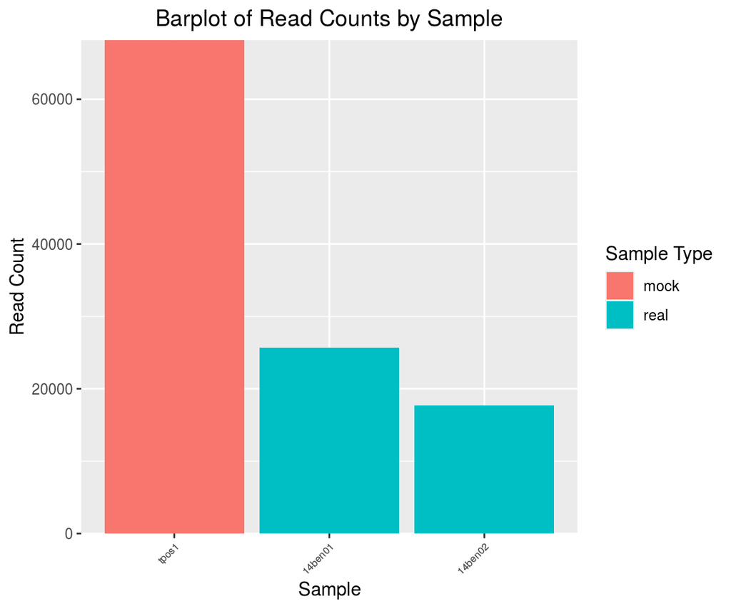

```r
sampleinfo <- file.path(demultiplexed_dir, "sampleinfo.csv")
Barplot_ReadCountBySample(read_count_df=read_count_df,
                          sample_replicate=F,
                          sampleinfo=sampleinfo
                          )
```

## Histogram_ReadCountByVariant

Histogram of read counts by ASV

- read_count_df: Input data frame
- `min_read_count`: Ignore variants with read count bellow this value
- `binwidth`: Width of bins

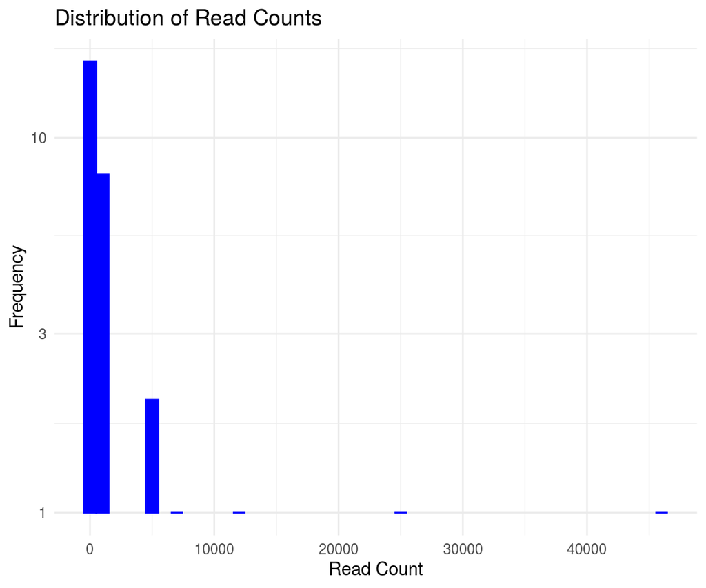

```r
Histogram_ReadCountByVariant(read_count_df,
                             min_read_count=10,
                             binwidth=1000
                             )
```

## Renkonen distances

Calculate the Renkonen distances among all replicates (compare_all=TRUE) or among replicates of the same sample (compare_all=FALSE) and plot them.

- read_count_df: Input data frame.
- `sampleinfo`: Data frame or CSV file containing info on sample types for each sample.

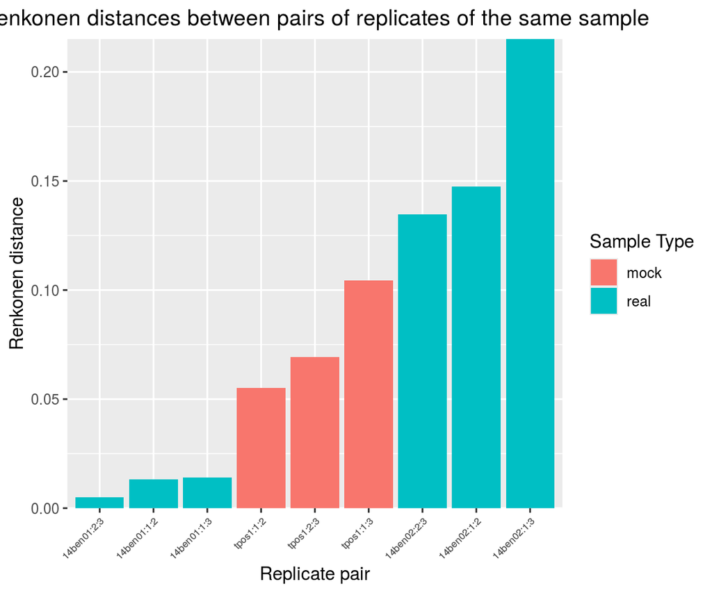

```r
sampleinfo <- file.path(demultiplexed_dir, "sampleinfo.csv")
renkonen_within_df <- MakeRenkonenDistances(read_count_df, compare_all=FALSE)
Barplot_RenkonenDistance(renkonen_within_df, sampleinfo=sampleinfo)
```

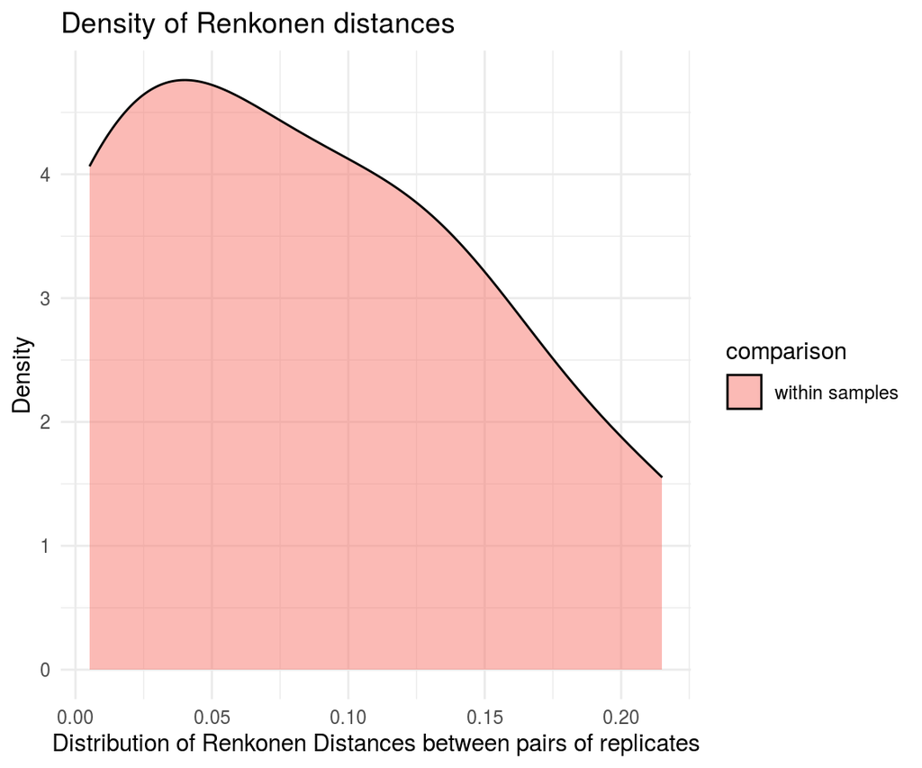

```r
DensityPlot_RenkonenDistance(renkonen_within_df)
```

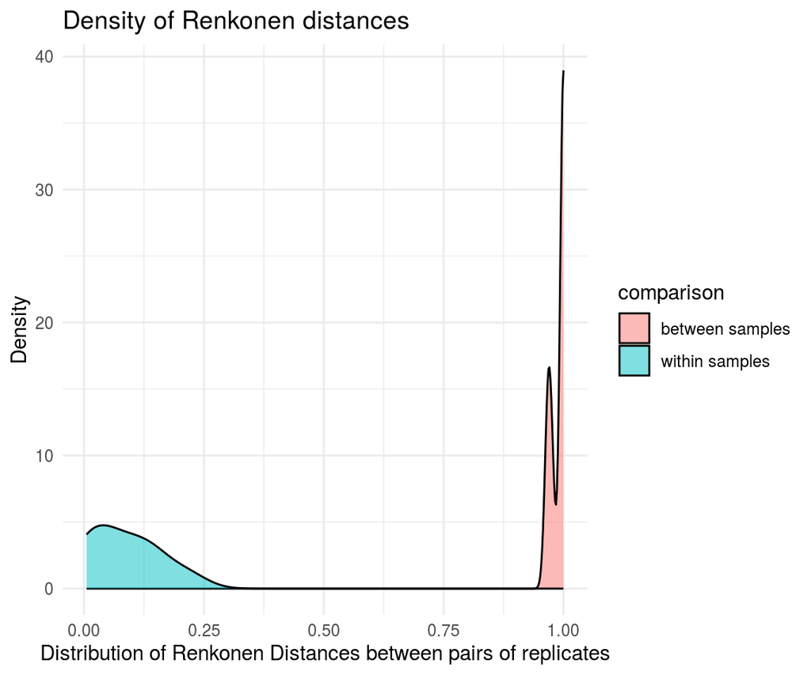

```r
renkonen_all_df <- MakeRenkonenDistances(read_count_df, compare_all=TRUE)
DensityPlot_RenkonenDistance(renkonen_all_df)
```

# I/O files and data frames

## fastqinfo

CSV file with information on input fastq files, primers, tags, samples with the following columns. Each line corresponds to a sample-replicate combination.

- tag_fw: Sequence tag on the 5’ of the fw read (NA if file is already demultiplexed)
- primer_fw: Forward primer (NA if primer has been trimmed)
- tag_rv: Sequence tag on the 3’ of the rv read (NA if file is already demultiplexed)
- primer_rv: Reverse primer (NA if primer has been trimmed)
- sample: Name of the sample (alpha-numerical)
- sample_type: real/mock/negative
- habitat: If real or mock samples are from different habitats that cannot contain the same type of organisms (e.g. terrestrial vs. marine), this information is used for detecting false positives. Use NA otherwise. Use NA for negative controls.
- replicate: Numerical id of a replicate within sample (e.g. Sample1 can have replicate 1, 2 or 3)
- fastq_fw: Forward fastq file
- fastq_rv: Reverse fastq file

## fastainfo

CSV file with information on input fasta files, primers, tags, samples with the following columns. Each line corresponds to a sample-replicate combination.

- tag_fw: Sequence tag on the 5’ of the fw read (NA if file is already demultiplexed)
- primer_fw: Forward primer (NA if primer has been trimmed)
- tag_rv: Sequence tag on the 3’ of the rv read (NA if file is already demultiplexed)
- primer_rv: Reverse primer (NA if primer has been trimmed)
- sample: Name of the sample (alpha-numerical)
- sample_type: real/mock/negative
- habitat: If real or mock samples are from different habitats that cannot contain the same type of organisms (e.g. terrestrial vs. marine), this information is used for detecting false positives. Use NA otherwise. Use NA for negative controls.
- replicate: Numerical id of a replicate (e.g. Sample1 can have replicate 1, 2 or 3)
- fasta: Fasta file
- Read_count: Number of reads in the fasta file. Optional.

## sampleinfo

CSV file with information on demultiplexed and primer trimmed fasta files and samples with the following columns. Each line corresponds to a sample-replicate combination.

- sample: Name of the sample (alpha-numerical)
- sample_type: real/mock/negative
- habitat: If real or mock samples are from different habitats that cannot contain the same type of organisms (e.g. terrestrial vs. marine), this information is used for detecting false positives. Use NA otherwise. Use NA for negative controls.
- replicate: Numerical id of a replicate (e.g. Sample1 can have replicate 1, 2 or 3)
- fasta: Fasta file
- Read_count: Number of reads in the fasta file. Optional.

## mock_composition

CSV file with the following columns.

- sample: Name of the mock sample
- action:
  - keep: Expected ASV in the mock, that should be kept in the data set
  - tolerate: ASV that can be present in a mock, but it is not essential to keep it in the data set (e.g. badly amplified organism)
- asv: sequence of the ASV
- taxon: Optional; Name of the organism
- asv_id: Optional; If there is a conflict between asv and asv_id, the asv_id is ignored

## known_occurrences

CSV file or data frame with the following columns.

- sample: Name of the sample
- action:
  - keep: Expected ASVs in a mock sample (corresponds to True Positives)
  - delete: False Positive occurrences: unexpected ASV in a mock sample; all occurrences in negative controls; occurrences in real samples corresponding to an incompatible habitats (e.g. an ASV mostly present in marine samples is unexpected in a freshwater sample)
- asv_id: optional
- asv: sequence of the ASV

## asv_list

This file lists ASVs and their IDs from earlier data sets. When provided (optional), identical ASVs in the present and earlier data sets have the same ID. New ASVs (not present in asv_list) will get unique IDs not present in asv_list. It is a CSV file with the following columns:

- asv_id: Unique numerical ID of the ASV
- asv: ASV sequence

## read_count_df

Data frame with the following columns:

- asv: Sequence of the ASV
- asv_id: Numerical ID of the ASV
- sample: Sample name
- replicate: Replicate within sample (Numerical)
- read_count: Number of reads of the ASV in the Sample-Replicate

## Reference database for taxonomic assignments

A data base is composed of two elements. A BLAST database (`blast_db`) and a `taxonomy` file.

`blast_db` can be produced using the `makeblastdb` command of BLAST:

```bash
makeblastdb -dbtype nucl -in [FASTA_FILE] -parse_seqids -taxid_map [TAXID_FILE] -out [DB_NAME]
```

- FASTA_FILE is a fasta file containing reference sequences.
- TAXID_FILE is a tab separated file with sequence IDs and the corresponding numerical taxIDs.
- DB_NAME is the name of the newly created BLAST database.

`taxonomy` is a **tab separated** csv file with the following columns:

- tax_id: Numerical Taxonomic ID. It can be a valid [NCBI taxID](https://www.ncbi.nlm.nih.gov/taxonomy), or arbitrary negative numbers for taxa not in NCBI.
- parent_tax_id: taxID of the closest parent of tax_id.
- rank: taxonomic rank (e.g. species, genus, subgenus, no_rank).
- name_txt: Scientifc name of the taxon.
- old_tax_id: taxIDs that have been merged to the tax_id by NCBI; if there is more than one for a given tax_id, make one line for each old_tax_id.
- taxlevel: Integer associated to each major taxonomic rank. (0 => root, 1=> domain, 2=> kingdom, 3=> phylum, 4=> class, 5=> order, 6=> family, 7=> genus, 8=> species). Levels in between have 0.5 added to the next highest level (e.g. 5.5 for infraorder and for superfamily).

**A ready to use COI database** in BLAST format and the associated taxonomy file can be downloaded from https://osf.io/vrfwz/. It was created using mkCOInr. It is also possible to make a [customized database](https://mkcoinr.readthedocs.io/en/latest/content/tutorial.html#customize-database) using mkCOInr. It can be dowloaded and extracted manually of using the `download_osf` function of vtamR. See Installation

# Glossary

- **ASV**: Amplicon Sequence Variant. Unique sequnece, caracterized by the number of reads in each sample-replicate.
- **asv_id**: Unique numerical ID of an ASV.
- **demultiplexing**: Sorting reads in a fasta (or fastq) file to different sample-replicates according to the tags present at their extremities.
- **dereplication**: The merged reads contain many identical sequenes. The dereplication reduces the dataset to unique sequences (ASV), and count the number of reads for each ASV in each sample-replicate.
- **data frame (or csv) in long format**: The read_count_df contains one line for each occurrence with asv_id, asv, sample, replicate, read_count columns. This is the standard format of keeping occurrences throughout the analyses, and it is smaller than the wide format, if there are many ASVs present in only one or few samples.
- **data frame (or csv) in wide format**: The read_count_df can be rearranged in wide format, where lines are ASVs, columns are sample(-replicates) and cells contain read counts. It is a more human friendly format and it is the base of writing an ASV table, where this information can be completed by taxonomic assignments and other informations.
- **false negative occurrence**: An expected ASV in a mock sample that is not found in the data.
- **false positive occurrence**: Un expected presence an ASV in a Sample.
  - all occurrences in all negative contols,
  - unexpected occurrences in mock samples
  - presence of an ASV in an incompatible habitat (e.g. ASV with high read count in samples of habitat 1 and low read count in habitat 2 is considered as FP in habitat 2).
- **habitat**: Habitat type of the organisms in real or mock samples. Use this only if organisms of the different habitats cannot appear in another haditat of the dataset. Use NA otherwise.
- **long format**: Each row is a single measurement. Typically, there are columns like ASV, sample, and read_count. This format is tidy and works well with many tidyverse functions.
- **Low Frequency Noise (LFN)**: ASVs present in low frequencies, likely to be due to errors.
- **merge**: Assemble a forward and reverse read pair to one single sequence.
- **mock sample**: An artificial mix of DNA of know organisms.
- **negative sample**: Negative control.
- **real sample**: An environmental sample.
- **replicate**: Technical or biological replicate of a sample. Replicates must have numerical identifiers. (e.g. sample tops1 have replicate 1, 2 and 3).
- **sample**: Name of the environmental or control sample. Must be alphanumerical, without space.
- **sample-replicate**: Each sample can have technical of biological replicates. sample-replicate refers to one replicate of a given sample.
- **sample_type**: real/mock/negative
- **singleton**: ASV with a single read in the whole data set.
- **tag**: Short sequence at the extremity of the amplicon. It is used at the demultiplexing step to identify the sample-replicate, where the read comes from.
- **taxIDs**: Numerical taxonomic identifier. It can be a valid [NCBI taxID](https://www.ncbi.nlm.nih.gov/taxonomy), or arbitrary negative numbers for taxa not in NCBI.
- **trimming**: Cut the extremities of the sequences. It can be based of sequences quality, or on the detection of a tag or primer.
- **true positive occurrence**: An expected occurrence in a mock sample.
- **Wide format**: In vtamR wide format data frames, each row is an ASV, and each column represents a sample. Read counts are in the cells.

# Troubleshooting

## LFNvariant eliminate most occurrences of a frequent ASV

`LFNvariant` will filter out all occurrences where

`(number of reads of the ASV in a sample-replicate) / (total number of read of the ASV) < cutoff`

As a consequence, if an ASV is present in most samples, there are many samples in the data set and the cutoff is relatively high, most occurrences can fall bellow the cutoff and the total read count of the ASV will decrease strongly at this step.

If the proportion of the read count of an ASV in the output compared to the input is less than `min_read_count_prop`, vtamR prints out a Warning. Take a close look at the variant. It can be the result of a general contamination, and in this case, the whole ASV could/should be eliminated from the data set. Otherwise, you might want to reduce the cutoff value for `LFNvariant`.

## Memory issues for running swarm on the whole dataset

Possible workarounds:

- Try to run Swarm sample by sample (`by_sample=T`).
- Run `global_read_count` first to eliminate singletons then swarm.

Both solutions make swarm a bit less efficient, but at least your analyses can get through.

## Memory issues in Merge on Windows

If input fastq files are very large and do not go through `Merge`, Try working with uncompressed input files.

## No or few sequences passing merge

If the amplicon is shorter than the reads, use `fastq_allowmergestagger=T`.